# Kostenoffenlegung als Wettbewerbsvorteil

Chancen und Potenziale der Kostentransparenz

# Motivation

Die Untersuchung von Kostentransparenz ist aus ökonomischer Sicht besonders spannend, da sie Einblicke in das Zusammenspiel von Marktverhalten, Preiswahrnehmung und Konsumentenvertrauen ermöglicht. In klassischen Märkten gilt Information als asymmetrisch verteilt - insbesondere Kostenstrukturen bleiben für Konsument:innen meist verborgen. Wenn Unternehmen jedoch freiwillig ihre Produktionskosten offenlegen, entsteht eine neue Form der Marktkommunikation, die sowohl auf das Kaufverhalten als auch auf die Markenbindung Einfluss nehmen kann.

In diesem Projekt beschäftigen Sie sich mit der ökonomischen Wirkung unterschiedlicher Formen von Kostentransparenz, darunter produktbezogene Einzelkosten-Offenlegung im Point-of-Sale oder auch verbal vermittelte Transparenz in Kombination mit Vertrauensmessung. Ziel ist es, zu untersuchen, wie sich diese Varianten auf Zahlungsbereitschaft, Vertrauen und wahrgenommene Preisfairness auswirken.

Kern dieser Ausarbeitung ist die Frage, inwiefern Kostentransparenz eine rationale Kaufentscheidung unterstützt oder über emotionale Mechanismen - etwa durch erhöhte Markenattraktivität - wirkt. Für die Analyse greifen Sie auf ein breites Methodenrepertoire zurück, das ökonomische Modellierung mit experimenteller Verhaltensforschung verbindet, und leisten so einen Beitrag zum besseren Verständnis moderner Konsumentenentscheidungen in transparenten Märkten. Für ihre Analyse verwenden Sie die Daten der folgenden Ausarbeitung:

**Mohan, B., Buell, R. W., & John, L. K. (2020). Lifting the veil: The benefits of cost transparency. Marketing Science, 39(6), 1105-1121.**

# Aufbau der Studie

1. Lesen Sie sich den folgenden Text zum Hintergrund und Aufbau der Studie durch und beantworten Sie nachfolgende Fragen dazu:

Der Ausgangspunkt der betrachteten Untersuchung war ein reales Ereignis: Ein Online-Händler stellte im Dezember 2013 ein hochwertiges Lederportemonnaie zum Verkauf. Einige Wochen später wurde auf den Produktseiten eine Infografik zur Kostenzusammensetzung ergänzt, allerdings versehentlich nur bei drei von fünf Farbvarianten. Obwohl der Händler diesen Fehler nicht beabsichtigte, entstand daraus ein sogenanntes natürliches Experiment, also eine reale Vergleichssituation mit kontrollierbaren Unterschieden. Die Verkäufe konnten analysiert werden, um zu überprüfen, ob die Offenlegung der Produktionskosten einen Einfluss auf das Kaufverhalten hatte.

Dieses natürliche Experiment lieferte erste Hinweise darauf, dass Kostentransparenz wirkt - und war damit die Basis für zwei gezielte Experimente im Labor, die Sie sich in diesem Projekt genauer anschauen sollen. Beide Laborexperimente knüpfen an die reale Ausgangslage an - gehen aber unterschiedliche Forschungsfragen an:

Experiment 1: In einem realitätsnahen Online-Setting wurde untersucht, ob Konsument:innen anders entscheiden, wenn sie Informationen zu Produktionskosten sehen. Hierbei sahen die Teilnehmer:innen eine Produktseite für einen Rucksack von Everlane - entweder mit oder ohne Kostenaufstellung (vgl. Abbildung 1: Kostentransparenz Infografik im Anhang). Zusätzlich wurde ein Vergleichsprodukt von J. Crew gezeigt (ohne Hinweise zur Kostenzusammensetzung). Die Teilnehmer:innen mussten entscheiden, von welchem Anbieter sie lieber einen Gutschein erhalten würden. Das Ziel der Forscher war es zu messen, ob Konsument:innen bei mehr Transparenz auch eher kaufen, folglich sich für diesen Gutschein entscheiden.

Experiment 2: Nachdem Experiment 1 zeigte, dass es einen Effekt der Kostentransparenz gibt, stellt sich die psychologische Anschlussfrage, warum es diesen Effekt gibt und wie dieser festzumachen ist. So sahen die Teilnehmer:innen im 2. Experiment ein fiktives Produkt - eine Schokoladentafel. In der Kontrollgruppe wurden nur übliche Produktinfos gezeigt. In der Treatmentgruppe gab es zusätzlich eine detaillierte Kostenaufstellung (vgl. Abbildung 2: Design der Schokoladenverpackung ohne und mit Kostentransparenz im Anhang). Im Anschluss wurden Vertrauen in die Marke und Kaufbereitschaft durch einen Fragebogen abgefragt. So sollte herausgefunden werden, ob Vertrauen der zentrale psychologische Mechanismus für die Kaufentscheidung der Kund:innen ist.

Beantworten Sie nun folgende Fragen:

1. Welches reale Ereignis war der Auslöser der Forschung?
2. Welche konkrete Verhaltensfrage steht im Mittelpunkt von Experiment 1 - Was wollten die Forscher:innen direkt am Kaufverhalten testen?
3. Welcher psychologische Faktor steht im Zentrum von Experiment 2 - und wie hängt er mit dem Kaufverhalten zusammen?

**a) Welches reale Ereignis war der Auslöser der Forschung?**  
Auslöser für die Forschung war ein sogenanntes natürliches Experiment. Dieses endstand dadruch, dass ein Online-Händler im Dezember 2013 ein hochwertiges Lederportemonnaie verkaufte. Bei drei der fünf Farbvarianten wurde eine Infografik zur Kostenzusammensetzung ergänzt.Der Fehler der dafür sorgte dass diese Grafik nicht bei allen Varianten hinzugefügt wurde sorgte für eine reale Vergleichssituation mit kontrollierbaren Unterschieden.

**b) Welche konkrete Verhaltensfrage steht im Mittelpunkt von Experiment 1 - Was wollten die Forscher:innen direkt am Kaufverhalten testen?**  
Den Teilnehmern des Experiments wurden eine Produktseite eines Rucksackes gezeigt, entweder mit oder ohne Kostenaufstellung. Zudem wurde ein Vergleichsprodukt einer anderen Marke gezeigt, hierbei immer ohne Kostenaufstellung. Die Teilnehmer sollten, dann entscheiden für welchen Rucksack sie lieber einen Gutschein haben wollen würden. Die Forscher wollten also messen, ob Konsument:innen bei mehr Transparenz auch eher kaufen, folglich sich für diesen Gutschein entscheiden.

**c) Welcher psychologische Faktor steht im Zentrum von Experiment 2 - und wie hängt er mit dem Kaufverhalten zusammen?**  
Im zweiten Experiment. stand Vertrauen als psycholohischer Faktor im Raum, Durch einen Fragebogen, sollte herrausgefunden werden, ob Dieser der zentrale psychologische Mechanismus für die Kaufentscheidung der Kund:innen ist.

Nachdem Sie nun die grundlegende Forschungsidee und Zielsetzung der beiden Experimente kennengelernt haben, befassen wir uns im nächsten Schritt vertiefend mit Experiment 1. Ziel ist es, den genauen Aufbau, sowie das konkrete Verhalten der Teilnehmer:innen besser zu verstehen.

2. Lesen Sie sich den folgenden Text zum Aufbau des ersten Experiments durch und beantworten Sie anschließend Fragen dazu:

Cost transparency refers to the disclosure of the costs to produce a good or provide a service. Although cost transparency is a strategy traditionally employed in the context of supplier-firm relationships, wherein the two-way sharing of cost information between parties facilitates collaboration on cost reduction measures, we investigate its effects within the context of consumer-firm relationships. Information on the costs associated with providing goods and services is rarely shared with consumers, but we provide evidence of when and why voluntarily doing so can increase consumers’ purchase interest. Specifically, building on the psychology of disclosure and trust, we posit that cost transparency, insofar as it represents an act of intimate disclosure, fosters trust. In turn, we propose that this heightened trust increases consumers’ willingness to purchase from the transparent firm. In the sections that follow, we discuss our central predictions and highlight alternative accounts. Then, we present experiments, conducted in the lab and in the field, that document the main effects of cost transparency, its underlying psychological drivers, and conditions that moderate its effects.

This first experiment explores how cost transparency influences consumer preferences in an online shopping context. The study was designed as a between-subjects randomized experiment using an incentive-compatible setup, meaning participants made real choices with the possibility of receiving a tangible reward. A total of 509 U.S.-based participants were recruited through Amazon Mechanical Turk (MTurk). Each participant was randomly assigned to one of two experimental conditions:

- Cost Transparency Condition: Participants were shown a simulated product page for a backpack sold by the retailer Everlane. This page included a cost breakdown infographic, listing the production costs such as materials, labor, transport, and duties, with a clearly stated total cost.
- Control Condition: Participants saw the same backpack from Everlane but without any cost information. In both conditions, participants also saw a comparable backpack from J. Crew, which does not practice cost transparency.

Participants were instructed to view both product pages and then asked which company they would prefer to receive a $50 gift card from. Their response served as the main behavioral outcome, representing a choice between the transparent vs. non-transparent retailer. To ensure accurate interpretation of the presented information, a comprehension check followed the main choice question. Participants were also asked for demographic information such as age, gender, income, and education, to allow for potential control variables in later analysis.

Beantworten Sie nun folgende Fragen:

1. Wie viele Personen nahmen final an dem Experiment teil?
2. Worin bestand der Unterschied zwischen der Transparenzbedingung und der Kontrollbedingung?
3. Welche Anreizstruktur wurde verwendet, um die Entscheidung der Teilnehmenden realistisch zu gestalten?
4. Wie unterschieden sich die beiden gezeigten Onlinehändler im Experiment?
5. Warum wurde im Anschluss an die Entscheidungsfrage ein Verständnischeck durchgeführt?
6. In der Beschreibung des Experiments wird von “between-subjects randomized experiment using an incentive-compatible setup” gesprochen. Was versteht man hierunter im Detail?

*Hinweis:* Für die Beantwortung der letzten Frage können Sie [diesen Artikel (Seite 1-5)](https://www.researchgate.net/publication/268269783_Incentives_in_Experiments_A_Theoretical_Analysis) als Grundlage verwenden.

**a) Wie viele Personen nahmen final an dem Experiment teil?**  
Am Experiment nahmen 509 Personen teil.

**b) Worin bestand der Unterschied zwischen der Transparenzbedingung und der Kontrollbedingung?**  
Der Unterschied zwischen der Transparenzbedingung und der Kontrollbedingung bestand darin, dass die eine Gruppe den Rucksack mit einer Kostenaufschlüsselung zu sehen bekam. Die Gruppe der Kontrollbedingung bekam den Rucksack ohne eine Kostenaufschlüsselung zu sehen.

**c) Welche Anreizstruktur wurde verwendet, um die Entscheidung der Teilnehmenden realistisch zu gestalten?**  
Als Anreiz wurde die Möglichkeit in aussicht gestellt einen Gutschein für den ausgewählten Rucksack zu erhalten.

**d) Wie unterschieden sich die beiden gezeigten Onlinehändler im Experiment?**  
Der eine Online-Händler zeigte eine Preisaufschlüsselung der andere nicht.

**e) Warum wurde im Anschluss an die Entscheidungsfrage ein Verständnischeck durchgeführt?**  
Um eine akkurate Interpretation der dargestellten Informationen zu gewährleisten.

**f) In der Beschreibung des Experiments wird von “between-subjects randomized experiment using an incentive-compatible setup” gesprochen. Was versteht man hierunter im Detail?**  
Es bedeutet, dass die Teilnehmer echte Entscheidungen trafen und die Möglichkeit bestand einen Preis zu erhalten.

# Daten

## Datenimport und -aufbereitung

Die Daten, die Sie für die nachfolgenden Analysen verwenden, wurden zu Replikationszwecken von den Autoren der Studie zur Verfügung gestellt und können hier heruntergeladen werden:

**Bhavya Mohan, Ryan W. Buell, Leslie K. John (2020) Lifting the Veil: The Benefits of Cost Transparency. Marketing Science 39(6):1105-1121. mksc.2019.1200.sm1.pdf**

Wir haben die Daten für Sie heruntergeladen und im Unterordner mit dem Namen `Daten` bereitgestellt. Für ihre Analyse werden die Dateien `Experiment1.csv` und `Experiment2.csv` genutzt. Für die Zusatzaufgabe ist die Datei `Experiment3.csv` relevant.

3. Lesen Sie den Datensatz `Experiment1.csv` aus dem Unterordner `Daten` in R ein. Nennen Sie den Datensatz in R `daten_exp1`.

Im Datensatz sind unterschiedliche Variablen enthalten. Weiterhin habe wir Ihnen ein Readme mit den Beschreibungen zu den Variablen bereitgestellt. Nutzen Sie dieses und den Text aus Aufgabe 2, um die Variablen zu beschreiben.

**Beschreibung der Variablen:**

- treatment: Angabe darüber ob die Teilnehmer die kostentransparente Website gesehen haben (1 = Kosten-Transparenz, 0 = Kontrolle).
- everlane: Angabe über Wahl der Geschenkkarte (1 = Wahl der Everlane-Geschenkkarte, 0 = Wahl der J Crew-Geschenkkarte).
- passed: Angabe über das Bestehen des Verständis-Tests (1 = Test bestanden, 0 = Test nicht bestanden).
- email_provided: Angabe einer E-Mail-Adresse (1 = E-Mail-Adresse angegeben, 0 = Keine E-Mail-Adresse angegeben).
- female: Angabe über das Geschlecht (optional) (1 = weiblich, 0 = männlich)
- age: Angabe über das Alter (optional)
- educ: Angabe über Bildungsabschluss (optional) (1 = Einige Jahre in der Schule, 2 = Schulabschluss, 3 = Einige Jahre College, 4 = Hochschulabschluss, 5 = Postgradual/beruflich).
- income: Angabe über Einkommensniveau (optional) (1 = Keines, 2 = Unter 60 Dollar, 3 = 60-499 Dollar, 4 = 500-999 Dollar, 5 = 1.000-1.999 Dollar, 6 = 2.000-2.999 Dollar, 7 = 3.000-3.999 Dollar, 8 = 4.000-4.999 Dollar, 9 = 5.000-7.499 Dollar, 10 = 7.500-9.999 Dollar, 11 = Über 10.000 Dollar, 12 = Weiß nicht/Bevorzuge keine Antwort).

## Deskriptive Analyse

Sie sollten sich im ersten Schritt einen Überblick über ihre Daten verschaffen.

4. Auf Basis des Datensatzes `daten_exp1` aus Aufgabe 3 erstellen Sie eine deskriptive Tabelle mit der Anzahl an Beobachtungen, den Mittelwerten, der Standardabweichungen, dem Median, sowie den Minima und Maxima für alle in `daten_exp1` enthaltenen Variablen.

Beschreiben und interpretieren Sie ihre Tabelle. Gehen Sie insbesondere auf die Verteilungen der einzelnen Variablen ein. Was fällt hier besonders auf.

Deskriptive Statistik aus daten_exp1

| Variable | Anzahl der Beobachtungen | Mittelwert | Standartabweichung | Minimum | Median | Maximum |
| --- | --- | --- | --- | --- | --- | --- |
| treatment | 509 | 0.50 | 0.50 | 0 | 0 | 1 |
| everlane | 509 | 0.63 | 0.48 | 0 | 1 | 1 |
| passed | 509 | 0.77 | 0.42 | 0 | 1 | 1 |
| email_provided | 509 | 0.56 | 0.50 | 0 | 1 | 1 |
| female | 509 | 0.49 | 0.50 | 0 | 0 | 1 |
| age | 505 | 37.59 | 11.74 | 18 | 35 | 81 |
| educ | 505 | 3.76 | 0.84 | 1 | 4 | 5 |
| income | 505 | 7.58 | 2.43 | 1 | 8 | 12 |

**Beschreibung:**  
Die Tabelle gibt für die Variablen (treatment, everlane, passed, email, female, age, educ und income) jeweils die Anzahl der Beobachtungen, den Mittelwert, die Standardabweichung, den Median, sowie das Minima und Maxima an.  
Insgesamt haben 509 Personen am Experiment teilgenommen. Die Variable „treatment“ ist eine binäre Variable und zeigt, ob die Teilnehmer:innen der Behandlungsgruppe mit Kostentransparenz (1) oder der Kontrollgruppe (0) zugeordnet wurden. Der Mittelwert von 0,50 deutet darauf hin, dass die Gruppen ungefähr gleich groß sind.

Die Variable „everlane“ gibt an, ob sich die Person für die Geschenkkarte des kostentransparenten Anbieters Everlane entschieden hat (1 = Ja, 0 = Nein). Hier liegt der Mittelwert bei etwa 0,63, was bedeutet, dass 63 Prozent der Teilnehmer:innen sich für Everlane entschieden haben.

Die Variable „passed“ misst, ob der Verständnischeck bestanden wurde, mit einem Mittelwert von 0,77 haben knapp 77 Prozent den Test bestanden. Die Angabe einer E-Mail-Adresse erfolgte bei rund 56 Prozent der Teilnehmer:innen.

Bezüglich der demografischen Variablen zeigen die Daten, dass etwa 48,5 Prozent weiblich sind („female“), das Durchschnittsalter liegt bei rund 37,6 Jahren mit einer Spannweite von 18 bis 81 Jahren. Der Bildungsstand („educ“) wird auf einer Skala von 1 bis 5 erfasst, wobei der Mittelwert von 3,76 auf überwiegend mittlere bis höhere Bildungsabschlüsse hinweist. Das Einkommen ist ordinal codiert und liegt mit einem Mittelwert von 7,58 im mittleren bis höheren Bereich.

**Interpretation:**  
Die Verteilung der „treatment“-Variable zeigt, dass die Randomisierung gut funktioniert hat und die Teilnehmer:innen gleichmäßig auf die Behandlungs- und Kontrollgruppe verteilt wurden. Die Wahl von Everlane als bevorzugtem Anbieter fällt mit knapp 63 Prozent deutlich zugunsten des Anbieters mit Kostentransparenz aus, was bereits einen Hinweis auf die Wirkung der Kostentransparenz geben kann.

Die hohe Bestehensrate des Verständnistests (77 Prozent) spricht dafür, dass die meisten Teilnehmer:innen die Experimentbedingungen gut verstanden haben, was die Validität der Ergebnisse unterstützt. Die Angabe der E-Mail-Adresse bei etwa der Hälfte der Personen könnte für die Auslosung der Gutscheine relevant sein, zeigt aber auch eine gewisse Zurückhaltung bei der Preisgabe persönlicher Daten.

Die Geschlechterverteilung ist ausgewogen, was eine gute Repräsentativität in Bezug auf das Geschlecht gewährleistet. Das durchschnittliche Alter von knapp 38 Jahren entspricht einer jungen bis mittelalten Erwachsenenstichprobe, die wahrscheinlich online-affin ist. Die Bildungs- und Einkommensniveaus liegen überwiegend im mittleren bis oberen Bereich, was auf eine eher gut situierte Stichprobe schließen lässt.

Insgesamt lässt die Beschreibung der Stichprobe darauf schließen, dass die Daten gut geeignet sind, um Rückschlüsse auf das Konsumentenverhalten in Bezug auf Kostentransparenz zu ziehen, da die Stichprobe breit gestreut und gut ausgewogen ist.

5. Im Datensatz `daten_exp1` gibt es Variablen für die keine Beobachtungen vorhanden sind.
- Gegeben ihrer Variablenbeschreibung in Aufgabe 3:
  - Macht es Sinn die Beobachtungen aus dem Datensatz zu entfernen, wenn für bestimmte Variablen keine Werte vorhanden sind?
  - Wenn ja, warum?
  - Wie viele Beobachtungen entfernen Sie dadurch aus ihrem Datensatz?

Entfernen Sie nun alle Beobachtungen (d.h. gesamte Zeilen aus dem Datensatz), bei denen für mindestens eine der erhobenen Variablen kein Wert vorliegt, da unvollständige Daten für die Analyse nicht berücksichtigt werden sollen.

Untersuchen Sie weiterhin, ob sich die Teilnehmer, die die Webseite mit der Kostentransparenz gesehen haben (Treatmentgruppe), systematisch von jenen unterscheiden, die die Kontrollversion gesehen haben. Auch wenn es sich um ein Experiment handelt, bei dem die Zuteilung zu den Gruppen zufällig erfolgt ist, sollten Sie dennoch prüfen, ob es unbeabsichtigte (systematische) Unterschiede zwischen den Gruppen gibt. Erstellen Sie hierfür eine Balancing-Tabelle, in der Sie die Mittelwerte von Alter (age), Geschlecht (female), Einkommensstufe (income) und Bildungsniveau (educ) zwischen den beiden Gruppen vergleichen, die Differenzen berechnen und mithilfe von T-Tests prüfen, ob diese Unterschiede statistisch signifikant sind.

- Beschreiben und interpretieren Sie ihre Tabelle.
  - Was fällt Ihnen in Bezug auf die p-Werte auf?
  - Was müssten Sie bei einer weiteren Regressionsanalyse berücksichtigen?

*Hinweis:* Die beiden Gruppen, die Sie in der Balancing Tabelle betrachten sollen, können aus den Werten (1 und 0) der Variable `treatment` abgeleitet werden.

- Ja, es macht Sinn die Zeilen mit mindestens einer NA beobachtung zu entfernen, da:
1. Dies sonst die Vergleichbarkeit zwischen Versuch- und Kontrollgruppe verzerren könnte.
2. Es das Balancing in Frage stellen könnte, z.B. unterschiedliche Altersstruktueren.
3. es t-Tests oder Regressionsmodelle beeinträchtigen könnte.

Anzahl der entfernten Beobachtungen aufgrund fehlender Werte: 4

Balancing-Tabelle: Vergleich der Mittelwerte zwischen Treatment und Kontrollgruppe

| Variable | Mittelwert Versuchsgruppe | Mittelwert Kontrollgruppe | Unterschied | p-Wert |
| --- | --- | --- | --- | --- |
| age | 37.273 | 37.913 | -0.640 | 0.541 |
| female | 0.490 | 0.488 | 0.002 | 0.964 |
| income | 7.763 | 7.405 | 0.358 | 0.098 |
| educ | 3.794 | 3.734 | 0.060 | 0.418 |

**Beschreibung:**  
Die Tabelle für die Variablen age, female, income und educ, jeweils den Mittelwert der Versuchsgruppe, den Mittelwert der Kontrollgruppe den Unterschied dieser Mittelwerte und den p-Wert.  
Das Mittlere Alter der Versuchsgruppe liegt mit 37,27 Jahren nahe an des Mittleren Alters der Kontrollgruppe, welches bei 37,91 Jahren liegt. Auch der Anteil der Frauen, Die Mittlere Bildung und das Mittlere Einkommen liegen alle nahe beinander. Auch der p-Wert zeigt Dies, alle p-Werte liegen über 0.05, daraus folgt das es zum 5%-Niveau keine signifikanten Unterschiede in den Kovariaten zwischen den beiden Gruppen gibt. Zwar ist der p-Wert beim Einkommen zum 10%-Niveau signifikant, dennoch sind beide Gruppenim Mittel in der Einkommengruppe 7.

**Interpretation:**  
Die Gruppen sind gut gebalanced, die p-Werte liegen alle über dem 5% Niveau, und auch alle, bis auf der des Einkommens, über dem 10% Niveau, wobei man hier auch bedenken sollte, das beide Gruppen im Mittel immernoch in derselben Einkommensgruppe 7 sind. Welche ein Einkommen von 3000 bis 3999USD hat. Daraus kann man schließen, das die Randomisierung gut funktioniert hat, und damit verzerrungen durch systematische Unterschiede unwahrscheinlich werden. Bei der Regression könnte man diese Variablen als Kontrollvariablen aufnehmen, um die Varianz zu reduzieren und die Präzison der Schätzung zu erhöhen.

Nachdem Sie sich in den vorangegangenen Aufgaben bereits mit der Verteilung der Daten und den Unterschieden zwischen den einzelnen Gruppen auseinandergesetzt haben, geht es nun um eine explorative Betrachtung von Zusammenhängen zwischen den zentralen Variablen im Datensatz.

6. In dieser Aufgabe führen Sie eine Korrelationsanalyse durch, um herauszufinden, ob und wie stark einzelne Merkmale - wie Alter, Bildung, Einkommen oder Geschlecht - mit der Treatment-Zugehörigkeit sowie der Entscheidung für die Everlane-Gutscheinkarte zusammenhängen.

Wählen Sie die folgenden Variablen aus dem Datensatz `daten_exp1` aus:

- treatment
- everlane
- age
- income
- educ
- female

Berechnen Sie die Korrelationsmatrix dieser Variablen. Visualisieren Sie die Matrix (als Tabelle oder Grafik), in der die Korrelationskoeffizienten und deren Stärke farblich dargestellt sind.

Beschreiben und interpretieren Sie ihre Tabelle/Grafik. Gehen Sie hierbei auch auf folgende Fragen ein:

- Was bedeutet ein positiver Zusammenhang (Korrelation) zwischen `treatment` und `everlane` im Kontext der Hypothese, dass Kostentransparenz die Entscheidung für Everlane beeinflusst?
- Warum kann eine Korrelation auf einen Zusammenhang hinweisen, aber nicht ausreichen, um einen kausalen Effekt nachzuweisen - selbst wenn wir wissen, dass `treatment` im Experiment zufällig zugewiesen wurde?
- Was nützt ihnen eine Korrelationsmatrix im Vergleich zu einem einfachen Mittelwertvergleich zwischen den Gruppen?

*Hinweis:* Für die Darstellung der Korrelationsmatrix können Sie z.B. das Paket corrplot verwenden.

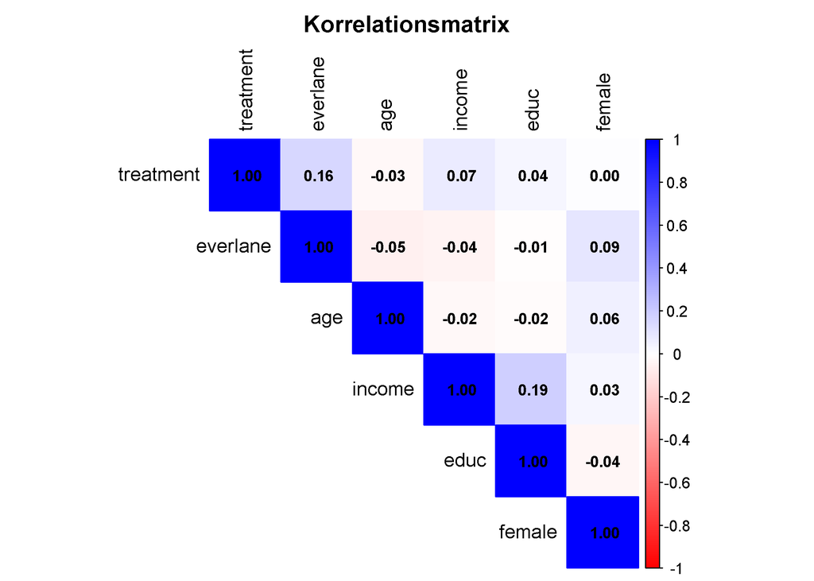

**Beschreibung:**  
Die vorliegende Korrelationsmatrix zeigt die Korrelationen der Variablen treatment, everlane, age, income, educ und female. Die Korrelationen liegen alle zwischen 0.19 und -0.05, womit alle nur schwach bis gar nicht oder sogar schwach negativ miteinander korrelieren.

**Interpretation:**  
Für uns am interessantesten ist wohl der Effekt den das treatment auf den Kauf eines Everlane Rucksackes hatte. Dieser ist schwach positiv, was durchaus ein Indiz sein könnte, dass die Bereitstellung von Informationen über die Kostenherkunft einen Effekt hatte. Allerdings sagt eine Korrelation nichts über die Richtung aus. Also könnte everlane auch die treatment-Variable beeinflussen. Außerdem könnte es auch ein Zufallsergebnis sein, vor allem bei einer kleinen Anzahl an Stichproben. Damit ist diese Korrelation lediglich ein statistischer Zusammenhang, kein kausaler Effekt!

**Was nützt eine Korrelationsmatrix gegenüber einem Mittelwertvergleich:**  
Man sieht die Beziehungen aller Variablen gleichzeitig, wodurch man sich schnell einen Überblick verschaffen kann. Des Weiteren kann man Trends innerhalb des Datensatzes erkennen, z.B. wie in Diesem, dass das Einkommen und die Ausbildung schwach miteinander Korrelieren. Zudem kann man den Datensatz auf Multikollinearität und starke Zusammenhänge von Kontrollvariablen überprüfen.

7. In Aufgabe 1 und 2 haben Sie gelesen, dass den Teilnehmern ein Angebot gemacht wurde, eine Everlane-Gutscheinkarte anzunehmen. Erzeugen Sie eine geeignete Grafik, die den durchschnittlichen Anteil der angenommenen Angebote (d.h. den Anteil, in dem die Everlane-Karte gewählt wurde) getrennt für die Treatment- und die Kontrollgruppe darstellt. Fügen Sie in der Grafik zusätzlich den Standardfehler der Mittelwerte ein. Führen Sie einen T-Test durch, um zu prüfen, ob der Unterschied im Mittelwert zwischen der Treatment- und Kontrollgruppe statistisch signifikant ist, und geben Sie das Testergebnis (den p-Wert) deutlich sichtbar in der Grafik an. Achten Sie dabei auf eine verständliche Beschriftung Ihrer Grafik sowie auf einen aussagekräftigen Titel.

Beschreiben und interpretieren Sie ihre Grafik. Gehen Sie insbesondere auf folgende Fragen ein:

- Welche Aussage lässt sich auf Basis des durchgeführten T-Tests treffen?
- Welche der in den vorherigen Aufgaben (vgl. Aufgabe 4 und 5) analysierten Faktoren könnten dazu beigetragen haben, dass ein signifikanter Unterschied im Anteil angenommener Everlane-Angebote zwischen Treatment- und Kontrollgruppe beobachtet wird?

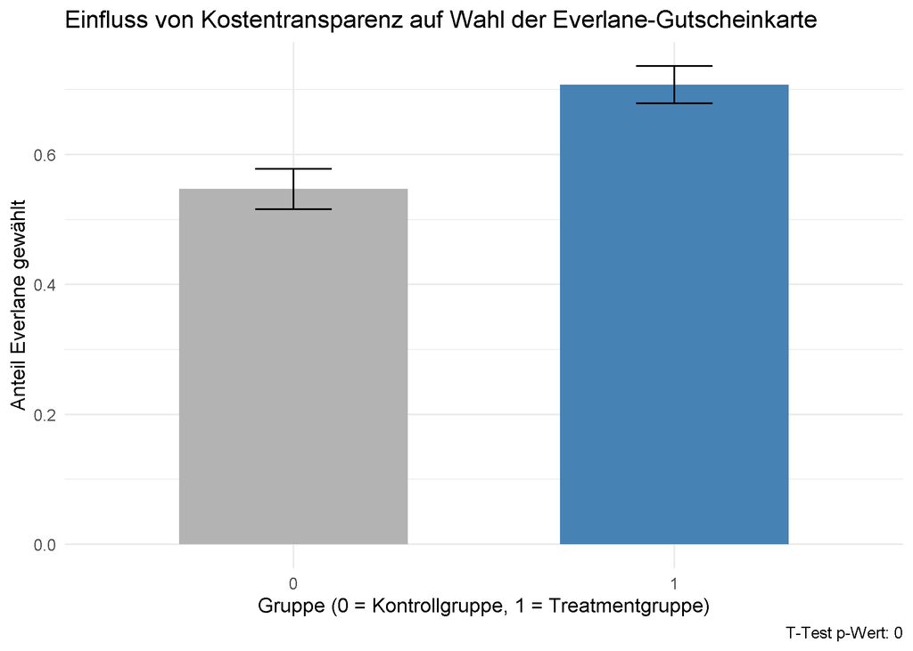

**Beschreibung:**  
Die vorliegende Grafik zeigt den Einfluss der Kostentransparenz auf die Wahl der Everlane-Gutscheine. Dabei ist die Grafik in zwei Säulen aufgeteilt. Eine Säulen für die Kontrollgruppe (Gruppe 0) und eine Säule für die Treatmentgruppe (Gruppe 1).  
Der p-Wert im t-Test ist <0.001, was bedeutet das es einen signifkanten Unterschied zwischen Versuchs/- und Kontrollgruppe gibt. Außerde, sieht man das die Versuchsgruppe um die 15 Prozentpunkte häufiger sich für den Gutschein für den Everlane Rucksack entschieden haben.

**Interpretation:**  
Die Bereitstellung von Information bezüglich der Preisgestaltung des Rucksackes hat einen positiven Einfluss auf die Entscheidungsfindung der Versuchsteilnehmer. Allerdings haben wir in Aufgabe 4 und 5 gesehen das mehr Teilnehmer der Versuchsgruppe in einer höheren Einkommengruppe sind, als die Teilnehmer:innen der Kontrollgruppe. Dieser Unterschied ist auf dem 10%-Niveau signifikant und könnte das Kaufverhalten potenziell beeinflusst haben. Dies könnte eine leichte verzerrung in den Daten erzeugen, deutet allerdings aber auch nicht auf ein starkes Ungleichgewicht in den Daten hin. Weiter gestützt wird Dies davon, dass das treatment in der Korrelationsmatrix mit keinen Wert außer everlane korreliert. Somit unterstützt die Hypothese, dass Kostentransparenz das Kaufverhalten positiv beeinflussen kann.

In den vorherigen Aufgaben des Projekts haben Sie sich bereits intensiv mit dem Experiment 1 auseinandergesetzt, in dem untersucht wurde, ob und wie die Offenlegung von Produktionskosten - also Kostentransparenz - das Konsumverhalten beeinflusst. Es wurde gezeigt: Wenn Konsument:innen transparent mitgeteilt wird, wie sich die Kosten eines Produkts zusammensetzen, steigt ihre Bereitschaft, bei dem entsprechend transparenten Unternehmen einzukaufen.

Diese Ergebnisse legen nahe, dass die Offenlegung sensibler Unternehmensinformationen (wie Produktionskosten) das Vertrauen der Konsument:innen in das Unternehmen stärkt und sie somit eher zu einem Kauf motiviert.

Doch was genau ist der psychologische Mechanismus hinter dieser Wirkung? Ist es tatsächlich das Vertrauen in das Unternehmen, das durch die Offenlegung sensibler Informationen gestärkt wird - und in der Folge die Kaufbereitschaft erhöht?

Um genau diese Frage zu beantworten, führen die Autoren ein weiteres Experiment durch, das den vermuteten psychologischen Vermittlungsmechanismus des Vertrauens genauer untersucht. Dabei wurde geprüft, ob Vertrauen tatsächlich als Mediator zwischen Kostentransparenz und Kaufinteresse wirkt. Hierzu wurde ein kontrolliertes Online-Experiment mit über 600 Teilnehmer:innen durchgeführt. Die Teilnehmenden wurden zufällig einer von zwei Bedingungen zugewiesen:

- In der **Kostentransparenz-Gruppe** (Treatment) wurde zusätzlich eine detaillierte Aufschlüsselung der Produktionskosten angegeben. Diese beinhaltete die einzelnen Kostenkomponenten (z.B. Kakaobutter, Verpackung, Arbeitskosten) sowie die Gesamtkosten der Schokoladentafel (vgl. Abbildung 2 im Anhang).
- In der **Kontrollgruppe** sahen die Teilnehmer die Verpackung einer fiktiven Schokoladenmarke namens „Cocoa Passion“. Diese enthielt nur die üblichen Informationen wie Zutaten, Nährwerte und eine Produktbeschreibung.

Ziel war es, zu untersuchen, ob die Offenlegung dieser sensiblen Informationen das Vertrauen der Konsument:innen in die Marke stärkt - und ob dieses Vertrauen wiederum die Kaufbereitschaft beeinflusst. In den nächsten Aufgaben werden Sie diese Studie genauer beleuchten, analysieren und evaluieren, ob sich die Hypothese empirisch bestätigen lässt.

8. Lesen Sie die Daten des zweiten Experiments (`Experiment2.csv`) in R ein. Nennen Sie den Datensatz `daten_exp2`. Benennen Sie die Variable `cost` in `treatment` um.

Untersuchen Sie, ob sich die Teilnehmer, die die Verpackung mit transparenter Kosteninformation gesehen haben, systematisch von jenen unterscheiden, die nur die Kontrollversion gesehen haben.

Erstellen Sie hierfür eine Balancing-Tabelle, in der Sie die Mittelwerte von Alter (age), Geschlecht (female), Einkommensstufe (income), Bildungsniveau (educ), Vertrauen (trust) und Kaufbereitschaft (wtb) zwischen den beiden Gruppen vergleichen, die Differenzen berechnen und mithilfe von T-Tests prüfen, ob diese Unterschiede statistisch signifikant sind. Nehmen Sie weiterhin die Anzahl an Beobachtungen in der Treatment- und in der Kontrollgruppe in ihre Tabelle mit auf.

Beschreiben und interpretieren Sie ihre Tabelle. Gehen Sie dabei insbesondere auf folgende Fragen ein:

- Was versteht man unter der Variable `wtb`?
- Was lässt sich aus der Größen der Stichprobe ableiten?
- Wo könnte es bei einer Regression (oder einem sonstigen Vergleich der Gruppen) zu Problemen kommen und was wären mögliche Auswirkungen?

*Hinweis:* Für die Beschreibung der `wtb` können Sie das bereitgestellte Readme nutzen.

Vergleich der Gruppen im Experiment 2

| Variable | Mittelwert Versuchsgruppe | Mittelwert Kontrollgruppe | Unterschied | p-Wert | Anzahl Versuchsgruppe | Anzahl Kontrollgruppe |
| --- | --- | --- | --- | --- | --- | --- |
| age | 34.063 | 36.272 | -2.208 | 0.016 | 306 | 308 |
| female | 0.475 | 0.424 | 0.051 | 0.207 | 306 | 308 |
| income | 6.791 | 6.960 | -0.169 | 0.372 | 306 | 308 |
| educ | 3.568 | 3.515 | 0.053 | 0.443 | 306 | 308 |
| trust | 5.273 | 4.825 | 0.448 | 0.000 | 306 | 308 |
| wtb | 4.273 | 3.740 | 0.533 | 0.001 | 306 | 308 |

**Was versteht man unter der Variable `wtb`?**  
Hier handelt es sich um eine Variable, die auf einer 7-Punkte-Skala wiedergibt wie wahrscheinlich es ist, das die Teilnehmer:innen sich dieses Produkt kaufen würde. (1 = Überhaupt nicht wahrscheinlich, 7 = Sehr wahrscheinlich)

**Beschreibung:** Die Tabelle zeigt für die Variablen age, female, income, educ, trust und wtb den Mittelwert der Versuchsgruppe, den Mittelwert der Kontrollgruppe, den Unterschied dieser Mittelwerte, den p-Wert, die Anzahl an Teilnehmern in der Versuchsgruppe und die Anzahl an Teilnehmern in der Kontrollgruppe.  
Das Geschlecht, Einkommen, und Bildung weißen keine signifikanten Unterschiede zwischen der Kontroll- und Versuchsgruppe auf. Allerdings ist der Altersunterschied zum 5%-Niveau signifikant. trust und wtb sind ebenfalls hochsignifikant, was allerdings zu erwarten ist, da es sich hier um die abhänigen Variablen handelt. Die Stichprobe enthält rund 300 Personen pro Gruppe.

**Interpretation:**  
An für sich sind die Gruppen vergleichbar. allerdings muss man mindestens auf das Alter achteny, da es sich hier um einen potenziellen Confounder handeln könnte. Man sollte also in der Regressionanalyse kontrollieren ob das Alter einen Einfluss auf die abhängigen Variablen hat. Außerdem ist die Stichprobe groß genug um mittlere Effekt zuverlässig erkennen zu können. Der Größenunterschied von 2 zwischen den Gruppen ist vernachlässigbar.

9. In ihrem Datensatz gibt es einige Beobachtungen ohne vorhandene Werte. Behalten Sie nur die Beobachtungen bei denen vollständige Werte vorliegen. Erzeugen Sie eine geeignete Grafik, welche den durchschnittlichen Anteil der ‘Kaufbereitschaft’ im zweiten Experiment für die Treatment- und Kontrollgruppe darstellt.

Die Grafik soll:

- die Mittelwerte der Kaufbereitschaft für beide Gruppen zeigen,
- die zugehörigen Standardfehler als Fehlerbalken visualisieren und
- das Ergebnis des T-Tests, der die Mittelwertdifferenz prüft, direkt in die Grafik integrieren.

Beschreiben und interpretieren Sie ihre Grafik.

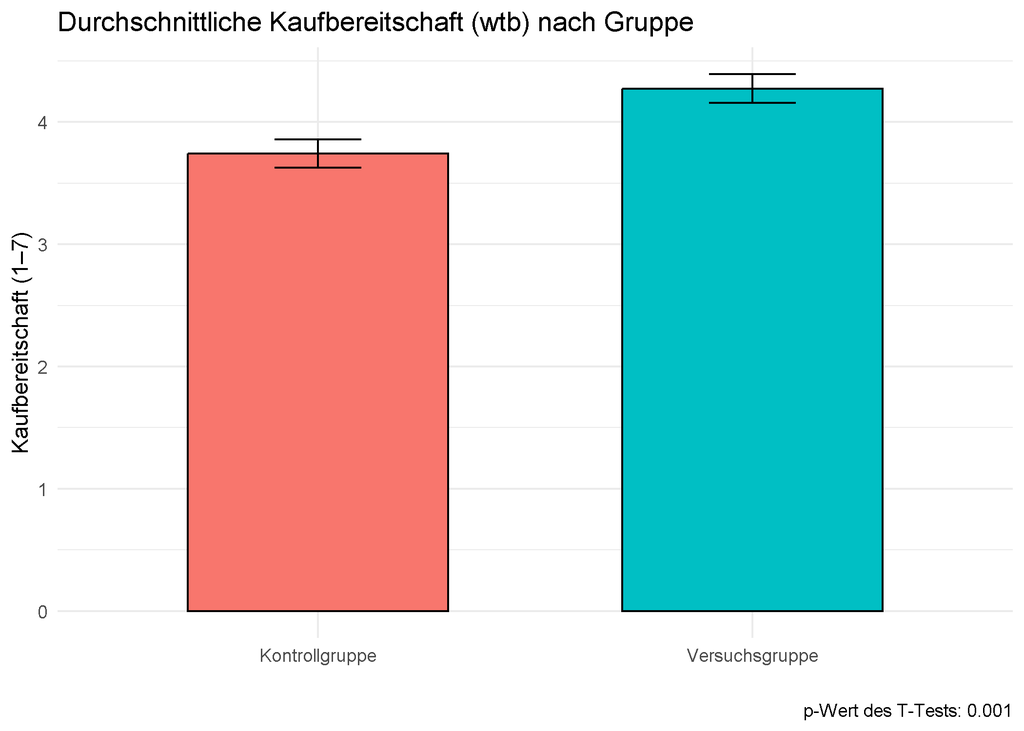

**Beschreibung:**  
Die vorliegende Grafik zeigt die durschnittliche Kaufbereitschaft (wtb) aufgeteilt in die Kontrollgruppe und die Versuchsgruppe.  
Der durchschnittliche wtb-Wert liegt in der Versuchsgruppe um etwa 0.5 Punkte höher als in der Kontrollgruppe. Die Fehlerbalken der Standartfehler überlappen sich nicht, was auf eine robuste Differenz hinweist. Außerdem zeigt der t-test das der Unterschied statistisch signifkant zum 1%-Niveau ist.

**Interpretation:**  
Die Aufschlüsselung der Kosten und Kommunikation dieser auf der Verpackung führt zu einersignifikant höheren Kaufbereitschaft. Damit zeigt sich, dass allein die zusätzlichen Informationen über die Preisgestaltung des Produktes einen positiven Einfluss auf das Kaufverhalten hat. Daraus lässt sich schließen, das Transparenz im Marketing ein wirksamer Hebel sein kann, um die Wahrnehmung von potentiellen Konsument:innen zu verbessern. Da in diesem Experiment zusätzlich nach dem Vertrauen in die Marke gefragt wurde, liegt die Vermutung nahe, dass Dieses als Mediator zwischen den bereitgestellten Informationen und der Kaufbereitschaft wirkt. Dies sollte man in weiteren Analysen überprüfen.

Nachdem Sie nun die Differenzen in der Kaufabsicht zwischen der Treatment- und der Kontrollgruppe im zweiten Experiment überprüft und getestet haben, geht es im nächsten Schritt darum, den möglichen Mediator Vertrauen genauer zu untersuchen. Hierfür sollen Sie sich in einem ersten Schritt das Vertrauen der Personen allgemein anschauen, um einen Eindruck zu dieser wichtigen Variable zu bekommen. Dafür werden Personen anhand **hohem und niedrigem** Vertrauen und deren Kaufbereitschaft für das Produkt unterteilt.

10. Erstellen Sie eine oder mehrere geeignete Grafik(en), die den Zusammenhang zwischen Vertrauen (Trust) und der Kaufabsicht (WTB) **unabhängig** der beiden Treatment- und Kontrollgruppen darstellen. Achten Sie auf eine passende Darstellung der Informationen.

Die Grafik(en) sollen folgende Informationen enthalten:

- Unterteilen Sie ihre Daten in Personen mit `hohem` und `niedrigem` Vertrauen. Nutzen Sie für die Unterteilung den Median des Vertrauens in ihren Daten als Schwellenwert.
- Abhängig der Einstufungen in `hohes` und `niedriges` Vertrauen soll nun die durchschnittliche Kaufbereitschaft dargestellt werden. Hier soll die Grafik so dargestellt werden, dass auf der x-Achse das Vertrauensniveau (“hoch” und “niedrig”) und auf der y-Achse die entsprechende Kaufbereitschaft abgebildet wird.
- Berechnen Sie weiterhin die Mittelwerte der beiden Vertrauensgruppen und visualisieren diese in geeigneter Art und Weise in ihren Grafik(en).
- Führen Sie einen t-Test durch, um zu prüfen, ob die Mittelwertsunterschiede zwischen den beiden Vertrauensgruppen statistisch signifikant sind. Geben Sie den p-Wert in der Grafik an.

Beschreiben und interpretieren Sie ihre Grafik(en). Beantworten Sie insbesondere folgende Fragen:

- Welche Implikationen hat ein signifikanter Unterschied für die Rolle von Vertrauen auf Kaufentscheidungen?
- Wie stark unterscheidet sich die Kaufbereitschaft zwischen Personen mit hohem und niedrigem Vertrauen?
- Könnte auf Basis ihrer Darstellung Vertrauen als Mediator zwischen dem Treatment und der Kaufbereitschaft fungieren?

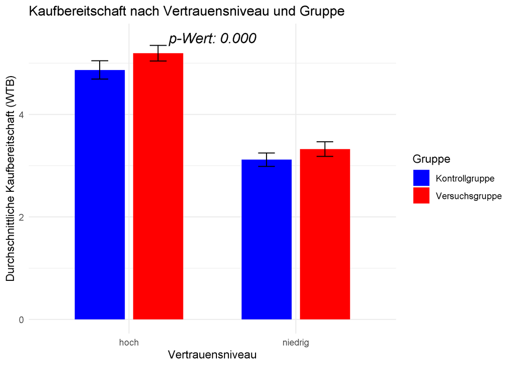

**Beschreibung:**  
Die Grafik zeigt die durchschnittliche Kaufbereitschaft in den beiden Vertrauensstufen für die jeweilige Gruppe. Bei den Vertrauensstufen wurde das Mittel des vertrauens der jeweiligen Gruppen als Schwellenwert verwendet. Die Kaufbereitschaft ist in beiden Gruppen bei der Versuchsgruppe höher als bei der Kontrollgruppe. Der Unterschied in der Kaufbereitschaft zwischen hohem Vertrauen und niedrigen Vertrauen liegt bei etwa 1.8 Punkten für beide Gruppen. Der der t-test zeigt das der Unterschied zwischen hohem und niedrigen vertrauen signifikant ist. Die Fehlerbalken überlappen sich leicht, was auf eine gewisse Streuung hindeutet.

**Interpretation:**  
Vertrauen scheint sich stehts positiv auf die Kaufbereitschaft auszuwirken, unabhängig von der Gruppe. Die Transparenz in der Preisgestaltung erhöht die Kaufbereitschaft zusätzlich in der Versuchsgruppe, sowohl bei niedrigem und hohem Vertrauenslevel. Der niedrige p-Wert, und der damit statistisch signifikante Effekt des Vertrauens legt nahe, dass Vertrauen ein zentraler psychologischer Mechanismus für die Wirkung den die Transparenz der Preisgestaltung auf die Kaufentscheidung hat, ist und somit als Mediator fungieren könnte.

# Regressionsanalyse

Sie haben nun ihren Datensatz kennengelernt und es scheint so, als ob insbesondere Personen, welche transparente Kosten sehen, dazu neigen, das Produkt zu kaufen. Doch um ihre deskriptiven Analysen zu erhärten, wollen Sie im folgenden eine Analyse mittels Regressionen durchführen.

11. Betrachten Sie hier noch einmal das erste Experiment (`daten_exp1`). Führen Sie eine Regression durch, bei der Ihnen `everlane` als abhängige Variable dient. Als erklärende Variable nutzen Sie das `treatment`. Erstellen sie eine weitere Regression, die zusätzlich noch für die folgenden Variablen kontrolliert:
- Alter
- Bildungsstufe
- Einkommen
- Geschlecht

Stellen Sie die Regressionsergebnisse in einer Tabelle mit stargazer oder modelsummary dar!

Beschreiben und interpretieren Sie ihre Ergebnisse. Gehen Sie insbesondere auf folgende Fragen ein:

- Lässt sich der Effekt des Treatments auf die Entscheidung der Kunden kausal interpretieren?
- Ist es wichtig auf weitere Faktoren zu kontrollieren?
- Beziehen Sie sich hier auch auf die Ergebnisse aus Aufgabe 5.

|  | Modell 1 | Modell 2 |
| --- | --- | --- |
| (Intercept) | 0.547*** | 0.686*** |
|  | (0.030) | (0.132) |
| treatment | 0.161*** | 0.155*** |
|  | (0.042) | (0.042) |
| age |  | -0.002 |
|  |  | (0.002) |
| educ |  | -0.001 |
|  |  | (0.026) |
| income |  | -0.012 |
|  |  | (0.009) |
| female |  | 0.091* |
|  |  | (0.042) |
| Num.Obs. | 509 | 505 |
| R2 | 0.028 | 0.039 |
| RMSE | 0.48 | 0.47 |

+ p < 0.1, * p < 0.05, ** p < 0.01, *** p < 0.001

**Beschreibung:**  
Die vorliegende Tabelle beschreibt eine Regression. In dieser wurde die Variable everlane als abhängige Variable und die Variable treatment als erklärende Variable verwendet. Zusätzlich wird in einer weiteren Regression auf die Variablen Alter, Bildungsstufe, Einkommen, Geschlecht kontrolliert.

Während die bisherigen Analysen zeigen, dass das Treatment einen Effekt hat, stellt sich nun die Frage, warum das so ist. Nun sollten Sie im weiteren Verlauf durch vertiefende Regressionsanalysen prüfen, ob dies auf das Vertrauen der Kunden zurückzuführen ist. Dazu betrachten Sie noch einmal den Datensatz zu Experiment 2 (`daten_exp2`) und untersuchen, ob das Treatment (Kunden sehen transparente Kostenstruktur) zu einer höheren Kaufabsicht führt, weil sie das Vertrauen der Konsumenten in das Unternehmen stärkt.

12. Schauen Sie sich den Einfluss der Kostentransparenz auf die Kaufabsicht in den folgenden zwei Regressionen genauer an und zeigen Sie ihre Ergebnisse nebeneinander:

**1. Regression:** Abhängige Variable ist die Kaufabsicht; die erklärende Variable ist das Treatment.

**2. Regression:** Wie in der 1. Regression, doch kontrollieren Sie hier zusätzlich auf die Variablen Alter, Einkommensniveau, Bildungsstufe und Geschlecht.

Stellen Sie die Regressionsergebnisse in einer Tabelle mit stargazer oder modelsummary dar!

Beschreiben und interpretieren Sie ihre Ergebnisse allgemein. Gehen Sie weiterhin auch speziell auf folgende Fragen ein:

- Sollten die Kontrollvariablen in ihrer zweiten Regression den Koeffizienten des Treatments ändern? Was würden Sie erwarten und warum? Nutzen Sie hierzu die Ergebnisse aus Aufgabe 8.
  - Vergleichen Sie die Regressionskoeffizienten der Treatment-Variable in der ersten und zweiten Regression. Gibt es hier einen signifikanten Unterschied in der Größe des Effekts?
- Bringt ihnen die Regression Vorteile gegenüber einer reinen Darstellung der Mittelwerte wie in Aufgabe 9?
- Ist der Effekt des Treatments auf die Kaufabsicht ihrer Ansicht nach kausal interpretierbar?
  - Welche Voraussetzungen müssen erfüllt sein, damit man diesen Regressionskoeffizienten als kausalen Effekt interpretieren kann?
  - Überlegen Sie sich, wie sich das Ergebnis verändern würde, wenn zusätzlich Vertrauen (trust) in das Modell aufgenommen wird. Würde sich der Effekt von `treatment` verändern? Warum oder warum nicht?

|  | Modell 1 | Modell 2 |
| --- | --- | --- |
| (Intercept) | 3.740*** | 3.702*** |
|  | (0.115) | (0.470) |
| treatment | 0.533** | 0.501** |
|  | (0.163) | (0.166) |
| age |  | -0.013+ |
|  |  | (0.007) |
| income |  | 0.023 |
|  |  | (0.036) |
| educ |  | 0.102 |
|  |  | (0.099) |
| female |  | -0.001 |
|  |  | (0.168) |
| Num.Obs. | 612 | 601 |
| R2 | 0.017 | 0.025 |
| RMSE | 2.02 | 2.01 |

+ p < 0.1, * p < 0.05, ** p < 0.01, *** p < 0.001

**Beschreibung:**  
Die vorliegende Tabelle beschreibt eine Regression. In dieser wurde die Kaufabsicht als abhängige Variable und das Treatment als erklärende Variable verwendet. Zusätzlich wird in einer weiteren Regression auf die Variablen Alter, Einkommensniveau, Bildungsstufe, Geschlecht kontrolliert.

Modell 1: zeigt, dass die Kostentransparenz einen positiven und statistisch signifikanten Effekt auf die Kaufabsicht hat. Teilnehmer:innen der Versuchsgruppe werden im Durchschnitt mit 0.53 Punkten höherer Kaufabsicht als die Kontrollgruppe assoziiert. Die durchschnittliche Kaufabsicht der Kontrollgruppe beträgt 3.74 Punkte.

**Interpretation:**  
Der positive Effekt der Kostentransparenz auf die Kaufabsicht ist statistisch signifikant, was darauf hinweist, dass die Transparenz der Preisgestaltung die Kaufbereitschaft fördert. Die Kontrollvariablen, also das Alter, das Einkommen, die Bildung und das Geschlecht, haben kaum Einfluss auf die Kaufbereitschaft. Dies legt nahe, dass der Effekt der Kostentransparenz unabhängig von diesen demografischen Faktoren ist. Der leicht negative Effekt des Alters ist marginal signifikant und könnte bedeuten, dass ältere Personen etwas weniger Kaufbereitschaft zeigen. Die erklärten Varianzen sind relativ gering, was darauf hinweisen könnte, dass viele weitere Faktoren die Kaufabsicht mitbestimmen.

**Sollten die Kontrollvariablen in ihrer zweiten Regression den Koeffizienten des Treatments ändern? Was würden Sie erwarten und warum?**  
Der treatment-Koeffizient zwischen Modell 1 (0.533) und Modell 2 (0.501) ist nahezu identisch, was darauf hindeutet, dass die Kontrollvariablen keine starken Confounder im Zusammenhang zwischen Versuchsgruppe und Kontrollgruppe sind. Dies erfüllt meine Erwartungen aus Aufgabe 8, in der wir gesehen haben, dass die Gruppen vergleichbar sind, dementsprechend sollten diese Variablen kaum einen Effekt haben.

**Vergleichen Sie die Regressionskoeffizienten der Treatment-Variable in der ersten und zweiten Regression. Gibt es hier einen signifikanten Unterschied in der Größe des Effekts?**  
Nein, beide treatment-Effekte sind auf dem 1%-Niveau signifikant und nahezu identisch. Der Unterschied der Koeffizienten ist nicht signifikant, was darauf hindeutet, dass die Hinzunahme der Kontrollvariablen die Schätzung des treatment-Effekts kaum beeinflusst.

**Bringt ihnen die Regression Vorteile gegenüber einer reinen Darstellung der Mittelwerte wie in Aufgabe 9?**  
Ja, die Regression ermöglicht es, potenzielle Confounder statistisch zu kontrollieren. Außerdem ermöglichen Schätzfehler und Konfidenzintervalle, die Größenordnung und die Richtung des Effekts eine präzisere Interpretiation.

**Ist der Effekt des Treatments auf die Kaufabsicht ihrer Ansicht nach kausal interpretierbar?**  
Nein, der Effekt ist nicht kausal Interpretierbar.

**Welche Voraussetzungen müssen erfüllt sein, damit man diesen Regressionskoeffizienten als kausalen Effekt interpretieren kann?**  
Dafür braucht man eine randomisierte Zuweisung in Versuchsgruppe und Kontrollgruppe, keine systematischen Unterschiede zwischen den Gruppen und keine unbeobachteten Confounder. An einer kausalen Interpretation scheitert es aufgrund dessen, dass wir nicht sicher sein können, alle Confounder beobachtet zu haben.

**Überlegen Sie sich, wie sich das Ergebnis verändern würde, wenn zusätzlich Vertrauen (trust) in das Modell aufgenommen wird. Würde sich der Effekt von treatment verändern? Warum oder warum nicht?**  
Vertrauen ist ein Confounder, das bedeutet sowohl die Wahrnehmung des Treatments als auch auf Kaufabsicht. Da Personen mit hohem Vertrauen eher auf das treatment ansprechen als auch eher kaufen würden, auch ohne treatment. Daraus folgt, das der treatment-Effekt verzerrt wäre, wenn man nicht auf trust kontrollieren würde. Trust hinzuzunehmen würde den Effekt wiederrum korrigieren.

Sie haben nun gesehen, dass es auch hier einen direkten Effekt des Treatments (transparente Kostenstrukur) auf die Kaufabsicht gibt. Doch um die dahinter liegenden Mechanismen zu verstehen, müssen Sie tiefer in psychologische Prozesse eintauchen. Experiment 2 zeigt dafür ein entsprechendes Design, um zu testen, ob Vertrauen als vermittelnder Mechanismus eine Rolle spielt. Im nächsten Schritt analysieren Sie nun selbst diese Beziehung mit theoretischen Modellen und Regressionsmethoden, um ein Gefühl dafür zu bekommen, wie sich direkte und indirekte Effekte voneinander unterscheiden.

13. Bevor Sie im nächsten Schritt ein konkretes DAG zu einem psychologischen Mediationsmechanismus erstellen, machen Sie sich zunächst mit den theoretischen Grundlagen von Directed Acyclic Graphs (DAGs) vertraut. DAGs (gerichtete azyklische Graphen) sind ein nützliches Werkzeug in der Kausalanalyse.

Beantworten Sie folgende theoretische Fragen zu DAGs:

- Wofür werden DAGs in der empirischen Forschung verwendet?
- Nennen und beschreiben Sie zwei zentrale Knotentypen in einem DAG: Confounder und Mediator.
- Worin besteht der zentrale Unterschied, ob Vertrauen als Kontrollvariable (Confounder) oder als Mediator behandelt wird - und warum ist Letzteres entscheidend für das Verständnis psychologischer Prozesse im vorliegenden Experiment?

**Wofür werden DAGs in der empirischen Forschung verwendet?**  
Directed Acyclic Graphs (DAGs) werden in der empirischen Forschung vor allem zur Analyse und Darstellung kausaler Zusammenhänge zwischen Variablen verwendet. Sie dienen dazu, Annahmen über die Struktur kausaler Zusammenhänge zwischen Variablen explizit darzustellen. Sie helfen Kausalbeziehungen von rein korrelativen Zusammenhängen zu unterscheiden. In einem DAG werden Variablen als Knoten und kausale Einflüsse als Pfeile dargestellt. Der Graph ist dabei azyklisch, es gibt keine Rückkopplungsschleifen.

**Nennen und beschreiben Sie zwei zentrale Knotentypen in einem DAG: Confounder und Mediator.**

- Confounder werden auch als Störfaktor bezeichnet. Sie beeinflussen sowohl Treatment als auch Outcome. Dadurch entsteht eine Scheinkorrelation zwischen diesen beiden Variablen. Auch dann, wenn kein kausaler Effekt besteht.
- Mediator werden auch als Vermittler bezeichnet. Sie liegen auf dem kausalen Pfad zwischen Treatment und Outcome. Das Treatment beeinflusst also den Mediator und der Mediator beeinflusst das Outcome. Mediatoren erklären also wie bzw. warum ein kausaler Effekt entsteht.

**Worin besteht der zentrale Unterschied, ob Vertrauen als Kontrollvariable (Confounder) oder als Mediator behandelt wird - und warum ist Letzteres entscheidend für das Verständnis psychologischer Prozesse im vorliegenden Experiment?**

- Unterschied zwischen Vertrauen als Confounder und Mediator:  
  Der Unterschied liegt in der kausalen Rolle von Vertrauen. Als Confounder beeinflusst Vertrauen sowohl die Intervention als auch das Ergebnis und muss kontrolliert werden, um Verzerrungen zu vermeiden.  
  Als Mediator hingegen ist Vertrauen eine Folge der Intervention und vermittelt deren Wirkung auf das Verhalten. In diesem Fall wäre eine Kontrolle nicht sinnvoll, da sie den kausalen Pfad unterbrechen würde. Vertrauen als Mediator zu betrachten, hilft also, Wirkmechanismen statt nur Effekte zu verstehen.
- Warum Vertrauen als Mediator wichtig ist:  
  Vertrauen als Mediator zu untersuchen, ist wichtig, um psychologische Prozesse sichtbar zu machen. Es erklärt, wie eine Intervention wirkt – etwa wenn Kostentransparenz das Vertrauen stärkt, was wiederum Verhalten beeinflusst. Die Analyse erklärt also nicht nur das “ob” sondern auch das “warum”.
14. Nutzen Sie nun das Directed Acyclic Graph (DAG), um die Beziehungen zwischen den Variablen Treatment (T), Vertrauen (V) und Kaufbereitschaft (K) zu analysieren und den vermuteten Mediationsmechanismus zu untersuchen.

Beschreiben und interpretieren Sie ihr DAG und die Beziehungen zwischen den Variablen. Gehen Sie insbesondere auf folgende Fragen und Aspekte ein:

- Begründen und erklären Sie die Struktur und den Aufbau ihres DAGs.
- Welche Annahmen müssen getroffen werden, damit Vertrauen tatsächlich als Mediator interpretiert werden kann?
- Welche Verzerrungen oder Störfaktoren könnten den Mediator-Effekt von Vertrauen beeinflussen? Wie könnte dies die Ergebnisse verzerren?

*Hinweis 1:* Für die Erstellung des DAGs können Sie das Paket `dagify` verwenden. Als Grundlage und Hilfsmittel können Sie die Vorlesungsfolien nutzen.

*Hinweis 2:* Eine direkte Visualisierung des DAGs in `R` ist schön, aber keine Pflicht. Sie können das DAG auch in Word/PowerPoint zeichnen und ihre Grafik mittels `include_graphics()` einfügen.

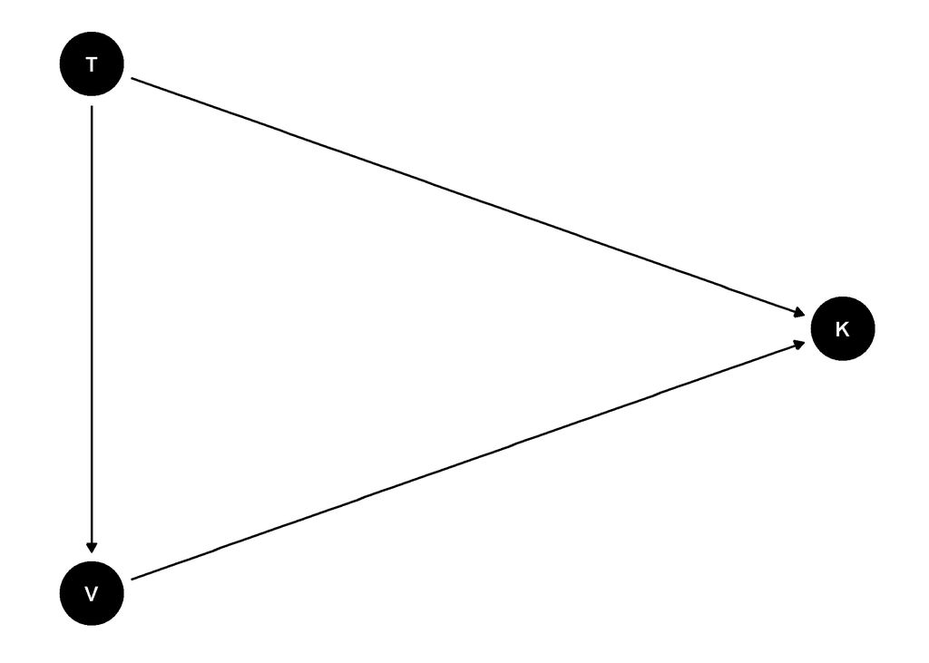

**Beschreibung:**  
Das dargestellte DAG zeigt die angenommene eziehung zwischen Treatment (T), Vertrauen (V) und Kaufbereitschaft (K).  
Dabei beeinflusst das Treatment sowohl das Vertrauen als auch die Kaufbereitschaft direkt. Das Vertrauen beeinflusst die Kaufbereitschaft ebenfalls.

**Interpretation:**

- Begründung der Struktur: Die Struktur spiegelt die Hypothese wieder, dass Vertrauen der zentrale Mechanismus ist, über den das Treatment auf das Konsumentenverhalten wirkt. Der direkte Pfad T → K wird ergänzt, da auch ein unmittelbarer Effekt plausibel ist (z.B. durch moralisches Signal ohne Vertrauen als Zwischenschritt).
- Notwendige Annahmen: Damit Vertrauen als Mediator gelten kann, müssen drei Annahmen erfüllt sein:  
  -Treatment beeinflusst Vertrauen (kausaler a-Pfad)  
  -Vertrauen beeinflusst Kaufbereitschaft (kausaler b-Pfad)  
  -Keine unbeobachteten Confounder, die sowohl Vertrauen als auch Kaufbereitschaft beeinflussen (z. B. Werte, Einstellungen).
- Mögliche Verzerrungen: Störfaktoren wie Konsumethik, politische Einstellung oder frühere Erfahrungen mit der Marke könnten sowohl Vertrauen als auch Kaufbereitschaft beeinflussen. Wenn solche Variablen nicht kontrolliert werden, kann der vermittelnde Effekt von Vertrauen überschätzt werden. Auch Messfehler in der Erhebung von Vertrauen könnten den Effekt verzerren.
15. Führen Sie nun eine Regression durch, bei der Ihnen `trust` (Vertrauen) als abhängige Variable dient. Weiterhin soll ihnen `treatment` als erklärende Variable dienen. Erstellen sie eine weitere Regression, die zusätzlich noch für die folgenden Variablen kontrolliert: Alter, Einkommensniveau, Bildungsstufe und ob die Personen weiblich sind.

Stellen Sie die Regressionsergebnisse in einer Tabelle mit stargazer oder modelsummary dar!

Beschreiben und interpretieren Sie ihre Ergebnisse. Gehen Sie bei der Interpretation der Ergebnisse insbesondere auf folgende Fragen ein:

- Macht es ihrer Ansicht nach Sinn auf die zusätzlichen Variablen in Regression 2 zu kontrollieren? Worauf müssen Sie besonders achten?
- Was bedeutet ein signifikanter positiver Koeffizient für treatment in Bezug auf Vertrauen?
- Warum ist dieser Pfad (Treatment ➝ Trust) notwendig, damit eine Mediation überhaupt möglich ist?
- Überlegen Sie, ob andere Faktoren, die Sie möglicherweise nicht berücksichtigt haben, diesen Zusammenhang ebenfalls erklären könnten.

|  | Ohne Kontrolle | Mit Kontrolle |
| --- | --- | --- |
| (Intercept) | 4.825*** | 4.716*** |
|  | (0.079) | (0.320) |
| treatment | 0.448*** | 0.454*** |
|  | (0.111) | (0.113) |
| age |  | -0.001 |
|  |  | (0.005) |
| income |  | -0.021 |
|  |  | (0.024) |
| educ |  | 0.058 |
|  |  | (0.067) |
| female |  | 0.179 |
|  |  | (0.114) |
| Num.Obs. | 612 | 601 |
| R2 | 0.026 | 0.035 |
| R2 Adj. | 0.024 | 0.027 |
| AIC | 2133.5 | 2095.6 |
| BIC | 2146.8 | 2126.4 |
| Log.Lik. | -1063.762 | -1040.795 |
| F | 16.188 | 4.291 |
| RMSE | 1.38 | 1.37 |

+ p < 0.1, * p < 0.05, ** p < 0.01, *** p < 0.001

**Beschreibung:**  
Die vorliegende Tabelle beschreibt eine Regression. In dieser wurde trust (Vertrauen) als abhängige Variable und das Treatment als erklärende Variable verwendet. Zusätzlich wird in einer weiteren Regression auf die Variablen Alter, Einkommensniveau, Bildungsstufe, Geschlecht kontrolliert.

Modell 1: Hier zeigt sich ein signifikanter positiver Effekt des Treatments (β = 0.448, p < 0.001), was auf einen höheren Vertrauenswert in der Treatment-Gruppe hindeutet.

Modell2: Auch hier, bleibt der Effekt fast unverändert (β = 0.454, p < 0.001). Die Kontrollvariablen selbst sind überwiegend nicht signifikant. Das Modell mit Kontrolle weist einen leicht höheren Erklärungswert auf (R² = 0.035 vs. 0.026), aber beide Modelle erklären nur einen kleinen Teil der Varianz.

**Interpretation:**  
Die Regressionsanalyse zeigt, dass eine transparente Preisgestaltung einen signifikant positiven Einfluss auf das Vertrauen der Konsument:innen hat. Dieser Effekt wird durch Alter, Einkommen, Bildung und Geschlecht nicht verzerrt. Dies spricht für einen robusten Zusammenhang und bestätigt, dass Vertrauen ein relevanter vermittelnder Mechanismus zwischen dem Treatment und der Kaufbereitschaft sein kann.

- Macht es Sinn, auf zusätzliche Variablen zu kontrollieren?  
  Ja, auch bei randomisierter Zuweisung kann es sinnvoll sein, Kontrollvariablen wie Alter oder Einkommen einzubeziehen, um die Präzision der Schätzung zu erhöhen und potenzielle Zufallsschwankungen auszugleichen. Wichtig ist jedoch, nur prä-treatment Variablen zu kontrollieren, da post-treatment Kontrollen den Effekt verzerren könnten.
- Was bedeutet ein signifikanter positiver Koeffizient für treatment?  
  Ein signifikanter positiver Koeffizient bedeutet, dass es einen kausalen Zusammenhang zwischen der Preistransparenz und dem Vertrauen gibt.
- Warum ist dieser Pfad (Treatment ➝ Trust) notwendig für eine Mediation?  
  Damit eine Mediation vorliegt, muss das Treatment einen Einfluss auf den Mediator (Vertrauen) haben. Ohne diesen Pfad kann kein indirekter Effekt über Vertrauen auf die Kaufbereitschaft entstehen.
- Könnten andere, unbeobachtete Faktoren den Zusammenhang erklären?  
  Ja, es könnte nicht gemessene Faktoren geben (z.B.:Konsumethik, persönliche Werte oder politisches Bewusstsein), welche sowohl das Vertrauen als auch die Reaktion auf das Treatment beeinflussen. Solche konfundierenden Variablen könnten den Zusammenhang verzerren, obwohl die Randomisierung bereits viele Verzerrungsrisiken reduziert.
16. Nachdem Sie nun den Effekt des Treatments auf das Vertrauen geschätzt und ausgewertet haben, sollen Sie nun testen, ob das Vertrauen als Mediator zwischen Treatment und Kaufabsicht wirkt.

Führen Sie eine Regression durch, bei der Ihnen die Kaufbereitschaft als abhängige Variable dient. Weiterhin sollen die erklärende Variablen nun `treatment`, sowie das Vertrauen (`trust`) umfassen. Erstellen sie eine weitere Regression, die zusätzlich noch auf Alter, Einkommensniveau, Bildungsstufe und ob die Personen weiblich sind, kontrolliert.

Stellen Sie die Regressionsergebnisse passend in einer Tabelle dar!

Beschreiben und interpretieren Sie ihre Ergebnisse. Gehen Sie bei der Interpretation der Ergebnisse insbesondere auf folgende Fragen ein:

- Was könnten Ihrer Ansicht nach Gründe sein, dass `treatment` jetzt nicht mehr signifkant ist? Woran könnt das im Detail liegen?
- Warum ist es wichtig, `trust` und `treatment` gemeinsam in einem Modell zu betrachten?
- Warum könnte `trust` eine “notwendige Bedingung” sein, damit Transparenz der Kostenstruktur zu höherer Kaufbereitschaft führt?

|  | Ohne Kontrolle | Mit Kontrolle |
| --- | --- | --- |
| (Intercept) | -0.120 | -0.155 |
|  | (0.259) | (0.457) |
| treatment | 0.174 | 0.129 |
|  | (0.139) | (0.140) |
| trust | 0.800*** | 0.818*** |
|  | (0.050) | (0.050) |
| age |  | -0.013* |
|  |  | (0.006) |
| income |  | 0.041 |
|  |  | (0.030) |
| educ |  | 0.055 |
|  |  | (0.082) |
| female |  | -0.148 |
|  |  | (0.140) |
| Num.Obs. | 612 | 601 |
| R2 | 0.310 | 0.327 |
| R2 Adj. | 0.308 | 0.320 |
| F | 137.018 | 48.027 |

+ p < 0.1, * p < 0.05, ** p < 0.01, *** p < 0.001

**Beschreibung:**  
Die vorliegende Tabelle beschreibt eine Regression. In dieser wurde die Kaufbereitschaft als abhängige Variable und das Treatment und das Vertrauen als erklärende Variablen verwendet. Zusätzlich wird in einer weiteren Regression auf die Variablen Alter, Einkommensniveau, Bildungsstufe, Geschlecht kontrolliert.

Modell 1: Hier zeigt sich, dass trust einen signifikanten positiven Einfluss auf Kaufbereitschaft hat (β = 0.800, p < 0.001),während der Effekt des Treatments positiv, aber nicht signifikant ist (β = 0.174). Das Modell erklärt etwa 31 % der Varianz in der Kaufbereitschaft.

Modell 2: Auch nach Einbezug von Alter, Einkommen, Bildung und Geschlecht bleibt der Effekt von Vertrauen stabil und signifikant (β = 0.818), während der Treatment-Effekt weiterhin nicht signifikant ist. Alter hat einen kleinen, aber signifikanten negativen Einfluss; die übrigen Kontrollvariablen sind nicht bedeutsam.

**Interpretation:**  
Die Tabelle zeigt, dass trust (Vertrauen) einen starken Einfluss auf die Kaufbereitschaft hat, während der direkte Effekt des Treatments in beiden Modellen nicht mehr signifikant ist. Dies zeigt also, dass der Einfluss der transparenten Preisgestaltung über Vertrauen vermittelt wird es liegt also ein Mediationsmechanismus vor.

- Warum ist treatment nicht mehr signifikant?  
  Der Treatment-Effekt verliert an Signifikanz, weil sein Einfluss bereits durch Vertrauen verarbeitet wird.Das Treatment wirkt demnach nicht direkt auf die Kaufbereitschaft, sondern indirekt über das gestärkte Vertrauen. Sobald Vertrauen im Modell enthalten ist, bleibt für einen zusätzlichen direkten Effekt, von Treatment, kaum noch Varianz übrig.
- Warum gemeinsam trust und treatment betrachten?  
  Nur wenn beide Variablen im selben Modell berücksichtigt werden, lässt sich erkennen, ob Vertrauen tatsächlich den Einfluss des Treatments erklärt. Dies ist entscheidend, um zwischen direktem und indirektem (vermitteltem) Effekt zu unterscheiden. Wir weisen so also eine echte Mediation nach.
- Warum ist trust eine notwendige Bedingung?  
  Wenn Transparenz das Vertrauen erhöht, und dieses Vertrauen wiederum die Kaufbereitschaft steigert, dann ist Vertrauen die zentrale vermittelnde Variable. Ohne diesen Vertrauenseffekt würde die transparente Preisgestaltung vermutlich keine oder nur eine schwache Wirkung auf das Kaufverhalten entfalten. Vertrauen ist somit ein Schlüsselelement im Wirkmechanismus zwischen Transparenz und Kaufbereitschaft.

In den vorangegangenen Modellen wurde untersucht, ob das Treatment (Kostentransparenz) das Vertrauen in das Unternehmen beeinflusst und ob Vertrauen wiederum mit der Kaufabsicht zusammenhängt.

17. Bewerten Sie das experimentelle Design der Studie 2. Gehen Sie dabei auch darauf ein, inwiefern Ihre Ergebnisse aus Aufgabe 13 bis 16 das theoretische Verständnis von Vertrauensbildung in der Konsumentenpsychologie bestätigt oder infrage stellt. Welche Stärken und Schwächen sehen Sie bezüglich der internen Validität und der Kausalitätsaussagen? Diskutieren Sie zudem kurz, inwiefern die Ergebnisse auf andere Bevölkerungsgruppen oder kulturelle Kontexte übertragbar sind.

*Hinweis:* Informationen zum Verständnis der Vertrauensbildung in der Konsumentenpsychologie können Sie [in dem folgenden Artikel](https://www.shs-conferences.org/articles/shsconf/pdf/2021/26/shsconf_appsconf2021_03019.pdf) auf Seite 2 bis 5 nachlesen.

Das experimentelle Design von Studie 2 basiert auf einer randomisierten Kontrollstudie, was eine hohe interne Validität gewährleistet. Die Randomisierung stellt sicher, dass Unterschiede zwischen den Gruppen auf das Treatment (Kostentransparenz) zurückgeführt werden können, nicht auf vorbestehende Unterschiede. Die Ergebnisse aus den Aufgaben 13 bis 16 unterstützen das theoretische Modell der Vertrauensbildung in der Konsumentenpsychologie, das Vertrauen als zentralen vermittelnden Faktor zwischen unternehmerischen Maßnahmen (z. B. Transparenz) und konsumbezogenen Entscheidungen beschreibt.

Stärken:

Kausale Interpretation möglich: Durch die Randomisierung und den klaren zeitlichen Ablauf (Treatment → Vertrauen → Kaufbereitschaft) lässt sich ein vermittelter Kausaleffekt über Vertrauen schlüssig ableiten.

Theoriegestütztes Design: Die Ergebnisse bestätigen zentrale Annahmen der Vertrauensforschung, insbesondere, dass Transparenz Vertrauen fördert, was wiederum Kaufentscheidungen positiv beeinflusst (vgl. SHS-Konferenzartikel).

Schwächen:

Begrenzte externe Validität: Die Stichprobe könnte z.B. in Alter, Bildung oder digitalem Verhalten nicht repräsentativ für die Gesamtbevölkerung sein. Auch kulturelle Unterschiede (z.B. in der Bedeutung von Unternehmensethik oder Preisverständnis) können die Generalisierbarkeit einschränken.

Selbstberichtete Maße: Sowohl Vertrauen als auch Kaufbereitschaft wurden vermutlich über Skalen abgefragt – diese subjektiven Einschätzungen sind anfällig für soziale Erwünschtheit und können von realem Verhalten abweichen.

Übertragbarkeit auf andere Kontexte: Die Ergebnisse sind plausibel übertragbar auf westliche, konsumethisch sensibilisierte Kontexte, in denen Konsument:innen Wert auf Transparenz und Nachhaltigkeit legen. In Kulturen mit weniger ausgeprägtem Misstrauen gegenüber Unternehmen oder mit anderen Konsumwerten (z.B. Preisdominanz statt Ethikorientierung) könnte der Effekt geringer ausfallen.

# Zusatzaufgabe

Zu Beginn des Projektes hatten wir erwähnt, dass die Experimente, welche im Projekt durchgeführt wurden, auf Grund eines Missgeschicks in der Online-Darstellung von unterschiedlichen Produkten zustande kam. Hier wurden von einem privat geführten Online-Händler Geldbörsen in fünf Farbvarianten angeboten, wobei beabsichtigt war, allen Farben eine einheitliche Kostentransparenz-Infografik zuzuordnen. Aufgrund eines Versehens wurde die Infografik jedoch nur bei drei Farben implementiert. Dieses zufällige Ereignis führte zu einer klaren Trennung zwischen den Produkten mit dieser und ohne diese Infografik. Das dadurch entstandene natürliche Experiment sollen Sie sich in der Zusatzaufgabe näher anschauen.

18. Lesen Sie sich den nachfolgenden Text zum Aufbau des natürlichen Experiments innerhalb dieses Papers durch und beantworten anschließend nachfolgende Fragen:

On December 2, 2013, a privately held online retailer launched a holiday gift shop with a single email to its mailing list, promoting a leather wallet offered in five colors (burgundy, black, grey, bone, and tan) and priced at $115.00. Later, at the end of January, to boost post-holiday sales, the retailer decided to add a cost transparency infographic to the online product detail pages for each of the wallet’s five color combinations. The retailer’s intention was to use the same infographic for all wallets since they differed only in color.

However, due to an inadvertent mistake, the infographic was not introduced for two of the wallet colors (bone and tan). Consequently, the cost transparency information was implemented for only three of the five wallet colors (burgundy, black, and grey) over a period of five weeks. This error created a natural experiment, enabling us to test the impact of cost transparency on wallet sales.

Therefore we have the following procedure:

- Operationalization of Cost Transparency: The infographic presented the total cost to produce the wallet, breaking it down into its specific components, namely: leather (14.68 US-Dollar), construction (38.56 US-Dollar), duties (4.26 US-Dollar), and transportation (1.00 US-Dollar). In addition, it included benchmark information indicating that the wallet had a 1.9x markup, in contrast to a 6x markup charged by a competitor. Because wallet colors serve as the basis for treatment assignment, the natural experiment compares “cost transparent” wallets (burgundy, black, and grey) to “non-transparent” wallets (bone and tan).
- Identification Strategy: We use a difference-in-differences approach to compare the daily sales between the treatment (cost transparency) and control (no cost transparency) groups before versus after the introduction of the infographic. By doing so, the design isolates the causal effect of cost transparency on the daily count of wallets sold for each color.
- Control Variables: Given that the cost transparency treatment was implemented by wallet color, and with only five available colors, it was necessary to control for potential confounders. For instance, we include a proxy for time-varying color popularity - the number of page views each wallet color received - and a proxy for time-varying inventory levels.

Beantworten Sie nun die folgenden Fragen in Bezug auf den vorherigen Text:

- Wie ist das natürliche Experiment aufgebaut, und warum wird es als solches klassifiziert?
- Welche Rolle spielt das zufällige Versäumnis, die Infografik bei zwei der fünf Farbvarianten einzuführen, in der Experimentstruktur?
- Warum ist es notwendig, Variablen wie Seitenaufrufe und Lagerbestandsproxies in die Analyse einzubeziehen?
  - Welche potenziellen Verzerrungen könnten auftreten, wenn diese Kontrollvariablen nicht berücksichtigt werden?
- Es handelt sich um ein natürliches Experiment, da die Zuweisung des Treatments nicht absichtlich oder kontrolliert im Rahmen eines Experiments erfolgte, sondern zufällig durch ein Versehen. Dadurch entstehen quasi-experimentelle Bedingungen, unter denen man Kausalität abschätzen kann. Der Aufbau ist wie folgt: Beobachtet werden die Verkaufszahlen über einen Zeitraum vor und nach der Einführung der Infografik. Diese ist bei drei Wallet-Farben vorhanden (burgundy, black, grey), bei zwei (bone, tan) jedoch nicht.
- Das Versehen erzeugt eine quasi-zufällige Variation in der Behandlung, die nicht systematisch mit anderen Faktoren zusammenhängt. Dadurch kann man die Einführung der Infografik als exogenen Schock betrachten, was eine kausale Interpretation des Unterschieds in den Verkaufszahlen zwischen den beiden Gruppen ermöglicht.
- 1. Die Seitenaufrufe zeigen die zeitabhängige Popularität eines Produkts und könnten die Verkaufszahlen unabhängig von der Infografik beeinflussen.
  2. Die Lagerbestands-Proxies sind relevant, da ein Produkt, das ausverkauft ist, nicht weiter verkauft werden kann, nicht wegen mangelnder Nachfrage, sondern weil kein Angebot mehr vorhanden ist.
  3. Ohne Kontrolle dieser Variablen könnte man fälschlicherweise einen Anstieg der Verkaufszahlen auf die Infografik zurückführen, obwohl das Produkt schlicht häufiger aufgerufen wurde. Umgekehrt könnten sinkende Verkaufszahlen fälschlicherweise als Wirkung der fehlenden Infografik interpretiert werden, obwohl das Produkt einfach ausverkauft war.
19. Lesen Sie weiterhin das Kapitel [“Difference-in-Differences” in Huntington-Klein (2021)](https://theeffectbook.net/ch-DifferenceinDifference.html), speziell Kapitel 18.1 und 18.2 und beantworten Sie die folgenden Fragen dazu:

Kann eine Difference-in-Differences-Regression helfen, den kausalen Effekt der Kostentransparenz auf die Verkaufszahlen zu identifizieren?

Gehen Sie bei der Beantwortung dieser Frage insbesondere auf die nachfolgenden Punkte ein:

- Welche Art von Variation nutzt eine DiD-Regression in diesem Fall zur Identifikation des Effekts?
- Welche Voraussetzung(en) müssen erfüllt sein, damit DiD eine gültige Kausalschätzung liefert?
  - Was bedeutet die „Parallel Trends“-Annahme in diesem Kontext?
  - Warum reicht es nicht aus, nur zu vergleichen, wie sich die Verkaufszahlen nach der Einführung verändert haben?
- Basierend auf dem Kontext des Buchkapitels zu Difference-in-Differences (DiD) und den Informationen aus `Aufgabe 18`, formulieren Sie bitte die **Regressionsgleichung**, mit der der Effekt der Kostentransparenzmaßnahme mithilfe eines DiD-Ansatzes untersucht werden kann.
  - Definieren Sie dabei klar alle verwendeten Variablen.
  - Stellen Sie die Regressionsgleichung in mathematischer Form dar.
  - Beschreiben und erklären Sie das von Ihnen aufgestellte Modell.
- Die DiD-Regression nutzt zeitliche Variation und Gruppenvariation. Man vergleicht also den zeitraum vor und nach der Einführung der Inforgrafik, und die Prdukte mit Infografik und solche ohne.
- Zwei Vorraussetzungen: 1. Die Trends in den verkaufszahlen müssen vor dem versenden der Infografik ähnlich verlaufen. -> das ist die Parrallel Trends Annahme 2. Ohne Kontrollgruppe kann man nicht zwischen der Infografik und anderen Effekten, wie z.B. Saisonale Trends unterscheiden.
- Die Regressionsgleichung könnte wie folgt aussehen:
  $$Y_{it} = \beta_0 + \beta_1 \cdot \text{Treat}_i + \beta_2 \cdot
  \text{Post}_t + \beta_3 \cdot (\text{Treat}_i \times \text{Post}_t) +
  \beta_4 \cdot \text{PageViews}_{it} + \beta_5 \cdot
  \text{Inventory}_{it} + u_{it}$$
  Wobei: - $Y_{it}$: Anzahl der verkauften Geldbeutel der Farbe i am Tag t
  - $\text{Treat}_i$: Dummy = 1, wenn Farbe i zur Treatment-Gruppe gehört (mit Infografik), sonst 0 - $\text{Post}_t$: Dummy = 1, wenn Tag t nach Einführung der Infografik, sonst 0
  - $\text{Treat}_i \times \text{Post}_t$: Interaktion – Treatment-Gruppe nach der Einführung
  - $\text{PageViews}_{it}$: Seitenaufrufe für Farbe i an Tag t
  - $\text{Inventory}_{it}$: Proxy für Lagerbestand von Farbe i an Tag t
  - $u_{it}$: Fehlerterm – unbeobachtete Einflüsse

Beschreibung: Das Modell schätzt den kausalen Effekt der Kostentransparenzmaßnahme, indem es den Behandlungseffekt, zeitliche Veränderungen und deren Interaktion berücksichtigt sowie für Seitenaufrufe und Lagerbestand kontrolliert.

20. Zum Abschluss des Projekts sollen Sie sich das oben beschriebene natürliche Experiment genauer anschauen. Lesen Sie hierzu die Daten (`Experiment3.csv`) in R ein. Nennen Sie den Datensatz `daten_exp3`. Erstellen Sie eine Variable `log_units`, die die logarithmierte Anzahl an verkauften Einheiten darstellt.

Erstellen Sie weiterhin eine passende Grafik, die die durchschnittliche Anzahl der verkauften Produkte je Treatment pro Woche abbildet. Fügen Sie weiterhin eine vertikale Linie für den 28. Januar 2014 in ihre Grafik ein, welche die Einführung der Kostentransparenz markiert.

Beschreiben und interpretieren Sie ihre Grafik. Gehen Sie insbesondere auf die Entwicklung der durchschnittlichen Verkaufszahlen in beiden Gruppen vor und nach dem 28. Januar ein. Gibt es visuelle Hinweise auf eine Wirkung der Kostentransparenz?

- Angenommen, beide Gruppen (Treatment und Kontrolle) zeigen vor der Einführung der Kostentransparenz einen gleich starken Anstieg der durchschnittlich verkauften Einheiten. Was würde das für die Interpretation der Maßnahme im Rahmen eines Difference-in-Differences-Ansatzes bedeuten?

*Hinweis:* Für die Ableitung der Wochen aus dem Datumsformat kann die Funktion `isoweek()` aus dem Paket `lubridate` verwendet werden.

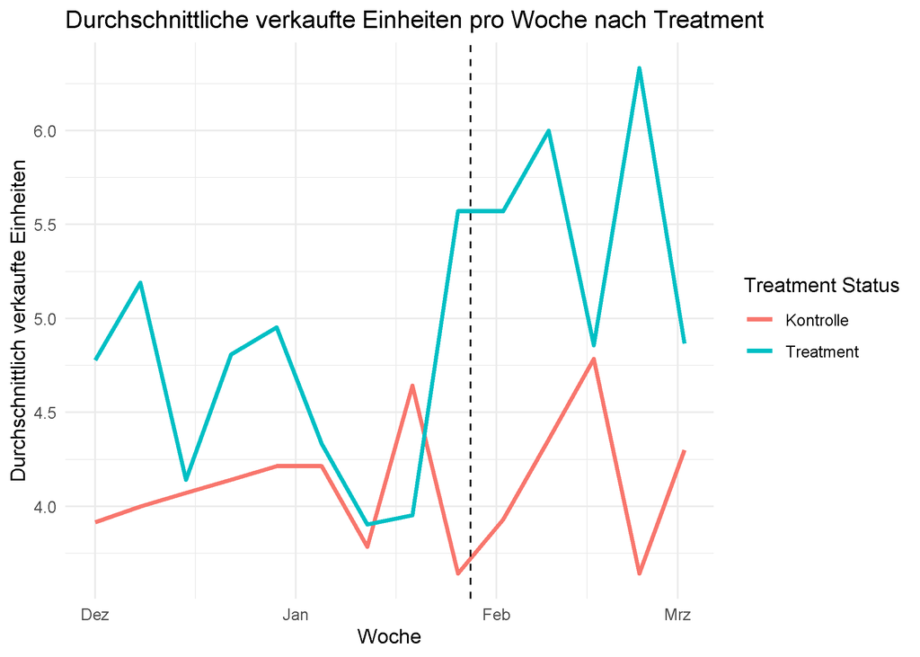

**Beschreibung:**  
Die X-Achse zeigt die Kalenderwochen von Dezember bis Anfang März, die Y-Aachse die durchschnittlich verkauften Einheiten pro Woche. Der Rote Graph ist die Kontrollgruppe, der Blaue ist die Versuchsgruppe. Die Gestrichelte Linie stellt den Einführungszeitpunkt der Infografik dar.

**Interpretation:**  
Vor dem 28. Januar entwickeln sich die Verkaufszahlen der beiden Gruppen unterschiedlich: Die Kontrollgruppe bleibt relativ konstant, während die Treatmentgruppe größere Schwankungen aufweist und bereits kurz vor der Einführung der Kostentransparenz einen deutlichen Anstieg zeigt. Diese Unterschiede deuten darauf hin, dass die Parallel-Trends-Annahme, eine zentrale Voraussetzung des DiD-Ansatzes, möglicherweise nicht erfüllt ist.

Nach der Einführung steigen die Verkaufszahlen in beiden Gruppen. Zwar liegt die Treatmentgruppe im Schnitt über der Kontrollgruppe, doch da der Anstieg bereits vor dem offiziellen Treatment beginnt, ist eine eindeutige kausale Zuordnung des Effekts schwierig. Visuell gibt es Hinweise auf eine Wirkung der Kostentransparenz, diese sind jedoch nicht klar isolierbar.

- Wenn beide Gruppen vor dem 28. Januar einen gleich starken Anstieg in den Verkaufszahlen zeigen würden, wäre die Parallel-Trends-Annahme erfüllt. Diese ist entscheidend, damit der DiD-Ansatz den Unterschied nach dem Treatment kausal auf die Infografik zurückführen kann. In diesem Fall würde der DiD-Ansatz eine valide Schätzung des kausalen Effekts der Kostentransparenz ermöglichen.
21. Erstellen Sie eine (mehrere) weitere passende Grafik(en), die die durchschnittlich verkauften Einheiten pro Tag in Treatment und Kontrolle vor und nach der Einführung der Kostentransparenz abbildet. Ergänzen Sie in ihrer Grafik die jeweiligen Standardfehler als Fehlerbalken. Beschreiben und interpretieren Sie ihre Grafik. Gehen Sie insbesondere auf die Unterschiede vor und nach der Einführung der Kostentransparenz ein.
- Inwiefern lassen sich daraus erste Hinweise auf einen möglichen Effekt des natürlichen Experiments erkennen?

*Hinweis:* Für die Erstellung der Grafik können Sie sich an Aufgabe 7 und 9 orientieren.

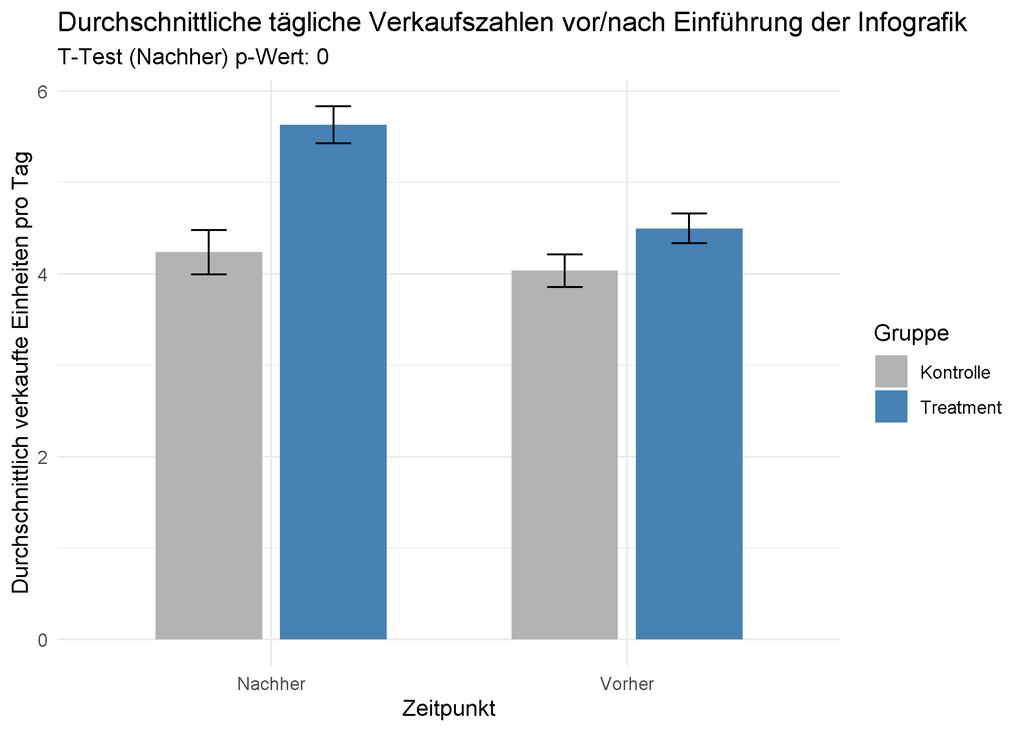

**Beschreibung:**  
Die Grafik zeigt die durchschnittlichen täglichen Verkaufszahlen vor (rechts) und nach (links) Einführung der Infografik. Dabei ist die Grafik aufgeteilt in Kontroll- und Treatmentgruppe. Die Fehlerbalken zeigen den Standardfehler der Mittelwerte an. Die Verkaufszahlen sind in der Treatmentgruppe sowohl vor als auch nach Einführung der Infografik höher als die der Kontrollgruppe. Der Abstand von Treatment und Kontrollgruppe wird nach Einführung der Infografik größer. Die Fehlerbalken der Standartfehler überlappen sich nicht, was auf eine robuste Differenz hinweist.

**Interpretation:**  
Die Grafik zeigt, dass nach der Einführung der Infografik die durchschnittlich verkauften Einheiten pro Tag in der Treatmentgruppe signifikant höher ausfallen als in der Kontrollgruppe. Dieser Anstieg deutet darauf hin, dass die Kostentransparenzmaßnahme einen positiven Einfluss auf das Kaufverhalten hatte und zu einem erhöhten Absatz der betroffenen Produkte führte.

- Inwiefern lassen sich daraus erste Hinweise auf einen möglichen Effekt des natürlichen Experiments erkennen?  
  Der sichtbare Anstieg der Verkaufszahlen in der Treatmentgruppe nach Einführung der Infografik – bei relativ stabilen oder schwächer ansteigenden Werten in der Kontrollgruppe – liefert erste Hinweise auf einen potenziellen Effekt des natürlichen Experiments. Insbesondere die Nicht-Überlappung der Fehlerbalken nach dem Stichtag spricht für einen signifikanten Unterschied zwischen den Gruppen, was auf einen kausalen Einfluss der Kostentransparenz auf die Verkaufszahlen hindeutet.
22. In der vorherigen Aufgabe haben Sie den Effekt von Kostentransparenz auf die Verkaufszahlen anhand eines deskriptiven Vergleichs untersucht. Dabei haben Sie die durchschnittlich täglich verkauften Einheiten je Treatment vor und nach der Einführung der Transparenzmaßnahme grafisch gegenübergestellt. In dieser Aufgabe sollen Sie diesen Effekt nun ökonometrisch genauer untersuchen, indem Sie den Difference-in-Differences Ansatz in einem Regressionsrahmen anwenden.

Untersuchen Sie den Effekt der Einführung von Kostentransparenz auf die Verkaufszahlen mithilfe einer Difference-in-Differences Regression. Verwenden Sie hierfür Beobachtungen an Werktagen, sowie am Wochenende (Montag bis Sonntag), mit positiven Verkaufszahlen.

Erstellen Sie insgesamt zwei Regressionsmodelle:

- Basismodell ohne Kontrollvariablen
- Modell mit Kontrolle für Wochentagseffekte

Stellen Sie die Ergebnisse anschaulich dar. Beschreiben und interpretieren Sie Ihre Ergebnisse. Gehen Sie insbesondere auf folgende Aspekte ein.

- Wie würden Sie die Größe des Effekts interpretieren, den Sie für `treated:post` erhalten haben?
- Welche Vorteile bringt es, log_units (logarithmierte Verkäufe) als abhängige Variable zu verwenden?
- Können Sie aus Ihrer Schätzung auf einen kausalen Effekt der Kostentransparenz schließen?
- Inwiefern hilft die Kontrolle für Wochentage dabei, Verzerrungen in der Schätzung zu vermeiden?
- Würden Sie auf Basis Ihrer Analyse eine Empfehlung zur Beibehaltung oder Ausweitung der Kostentransparenz geben?
- Worin könnten ihrer Ansicht nach Probleme liegen bei der Betrachtung eines natürlichen Experiments, die die Ergebnisse verzerren könnten?

*Hinweis 1:* Nutzen Sie für die Schätzung die `feols()`-Funktion aus dem fixest-Paket.

*Hinweis 2:* Nutzen Sie die logarithmierten täglichen Verkaufszahlen als abhängige Variable.

|  | Ohne Kontrolle | Mit Wochentag-Kontrolle |
| --- | --- | --- |
| (Intercept) | 1.285*** | 1.292*** |
|  | (0.049) | (0.075) |
| treated | 0.105+ | 0.106+ |
|  | (0.063) | (0.063) |
| post | 0.066 | 0.064 |
|  | (0.077) | (0.077) |
| Treatment × Post | 0.182+ | 0.182+ |
|  | (0.099) | (0.099) |
| factor(weekday)Donnerstag |  | -0.098 |
|  |  | (0.087) |
| factor(weekday)Freitag |  | 0.041 |
|  |  | (0.089) |
| factor(weekday)Mittwoch |  | 0.120 |
|  |  | (0.087) |
| factor(weekday)Montag |  | -0.004 |
|  |  | (0.088) |
| factor(weekday)Samstag |  | 0.005 |
|  |  | (0.089) |
| factor(weekday)Sonntag |  | -0.123 |
|  |  | (0.089) |
| Num.Obs. | 470 | 470 |
| R2 | 0.060 | 0.081 |
| RMSE | 0.51 | 0.51 |
| Std.Errors | IID | IID |

+ p < 0.1, * p < 0.05, ** p < 0.01, *** p < 0.001

**Beschreibung:**  
Die vorliegende Tabelle beschreibt zwei Regressionsmodelle zur Untersuchung des Effekts von Kostentransparenz auf Verkaufszahlen. Als abhängige Variable wurden logarithmierte tägliche Verkaufszahlen verwendet. Erklärt wird dieser Wert durch die Treatment-Zugehörigkeit, die Zeit nach Einführung der Maßnahme (post), sowie deren Interaktion. Im zweiten Modell wird zusätzlich auf den Wochentag kontrolliert.

Modell 2: Auch nach Kontrolle für Wochentagseffekte bleibt der Effekt der Interaktion stabil (β = 0.182, p < 0.1). Die Wochentage zeigen teils kleinere, aber meist nicht signifikante Effekte. Der Erklärungsgehalt des Modells steigt leicht auf rund 8%.

**Interpretation:**  
Die Ergebnisse der Difference-in-Differences-Regression zeigen, dass die Interaktion treated × post, also der Effekt der Kostentransparenz auf die logarithmierten Verkaufszahlen, in beiden Modellen positiv und statistisch schwach signifikant ist (p < 0.1). Der geschätzte Koeffizient von 0.182 lässt sich als ungefähr 20% Zuwachs an durchschnittlichen Verkäufen interpretieren. Das deutet darauf hin, dass die Einführung der Kostentransparenzmaßnahme zu einem merklichen Anstieg der Verkaufszahlen in der Treatmentgruppe führte – und zwar über das hinaus, was sich durch allgemeine Trends (post) oder Unterschiede zwischen Gruppen (treated) erklären lässt.

- Wie würden Sie die Größe des Effekts interpretieren, den Sie für treated:post erhalten haben?: Ein Effekt von 0.182 in logarithmierter Form bedeutet, dass die Verkaufszahlen in der Treatmentgruppe nach der Intervention im Schnitt etwa 20% höher lagen als ohne die Maßnahme – unter sonst gleichen Bedingungen.
- Welche Vorteile bringt es, log_units (logarithmierte Verkäufe) als abhängige Variable zu verwenden? Die Verwendung der logarithmierten Verkaufszahlen hilft, prozentuale Veränderungen zu modellieren. Sie reduziert die Verzerrung durch Ausreißer und sorgt dafür, dass Unterschiede bei kleinen und großen Verkaufszahlen vergleichbar gewichtet werden.
- Können Sie aus Ihrer Schätzung auf einen kausalen Effekt der Kostentransparenz schließen? Die DiD-Strategie erlaubt unter bestimmten Annahmen (insbesondere Paralleltrendannahme) eine kausale Interpretation. Da die Kontrollgruppe als Kontrafaktikum dient, kann man den Effekt weitgehend auf die Maßnahme zurückführen – vorausgesetzt, es gab keine anderen zeitgleich wirksamen systematischen Unterschiede zwischen Gruppen.
- Inwiefern hilft die Kontrolle für Wochentage dabei, Verzerrungen in der Schätzung zu vermeiden? Der Verkauf kann systematisch vom Wochentag abhängen (z.B. weniger Umsatz sonntags). Die Kontrolle für diese Effekte reduziert Verzerrung durch saisonale Schwankungen, was die Schätzung des Haupteffekts präziser macht.
- Würden Sie auf Basis Ihrer Analyse eine Empfehlung zur Beibehaltung oder Ausweitung der Kostentransparenz geben? Aufgrund des positiven und ökonomisch relevanten Effekts der Kostentransparenz auf die Verkaufszahlen, wäre eine Beibehaltung oder sogar Ausweitung dieser Maßnahme sinnvoll. Weitere Tests könnten ihre Wirksamkeit langfristig absichern.
- Worin könnten ihrer Ansicht nach Probleme liegen bei der Betrachtung eines natürlichen Experiments, die die Ergebnisse verzerren könnten? Mögliche Verzerrungsquellen sind z.B. unbeobachtete Störfaktoren, Selektionsverzerrung (z.B. wenn bestimmte Produkte eher in die Treatmentgruppe fielen) oder Nicht-Erfüllung der Paralleltrendannahme. Diese Faktoren könnten die Schätzung verfälschen, ohne dass dies direkt sichtbar ist.

# Literatur

Mohan, B., Buell, R. W., & John, L. K. (2020). Lifting the veil: The benefits of cost transparency. Marketing Science, 39(6), 1105-1121. https://doi.org/10.1287/mksc.2019.1200

# Anhang

## Mediator

Im Rahmen von Mediationen ist der Mediator eine Variable, die den erklärenden Zusammenhang zwischen einer unabhängigen und einer abhängigen Variable vermittelt. Dabei wird untersucht, inwieweit der Einfluss der unabhängigen Variablen (z.B. Kostentransparenz) auf die abhängige Variable (z.B. Kaufabsicht) über einen vermittelnden Mechanismus - wie das Vertrauen der Kunden - erfolgt.

1. **Mediatoreffekt**: Der Mediatoren-Effekt, oft als ACME (Average Causal Mediation Effect) bezeichnet, beschreibt den indirekten Effekt, den die unabhängige Variable auf die abhängige Variable über den Mediator ausübt. Ist dieser Effekt signifikant, signalisiert dies, dass ein wesentlicher Teil des gesamten Einflusses über den vermittelnden Mechanismus läuft. Gleichzeitig kann ein nicht-signifikanter direkter Effekt (ADE - Average Direct Effect) darauf hindeuten, dass der Mediator den hauptsächlichen Erklärungsmechanismus darstellt.
2. **Funktion und Wirkung des Mediators**: Analog zum Konzept der signalgebenden Funktion bei Statussymbolen - deren Wert unter anderem von der Exklusivität und dem sozialen Kontext abhängt - fungiert der Mediator als vermittelnder Kanal, der erklärt, wie und warum der ursprüngliche Zusammenhang zwischen zwei Variablen zustande kommt. Der Mediator „überträgt“ quasi den Effekt der unabhängigen Variable auf die abhängige Variable. Dadurch kann in Modellen, in denen der direkte Zusammenhang zwischen der unabhängigen und der abhängigen Variable durch die Einbeziehung des Mediators verschwindet oder abgeschwächt wird, abgeleitet werden, dass der Mechanismus über den Mediator läuft. Dies ermöglicht ein tieferes Verständnis der zugrundeliegenden psychologischen Prozesse - etwa wie das Vertrauen der Kunden die Wirkung von Kostentransparenz auf deren Kaufabsicht vermittelt.

Zusammengefasst spielt der Mediator eine zentrale Rolle bei der Aufklärung der kausalen Mechanismen, indem er als vermittelnder Faktor zwischen Ursache und Wirkung identifiziert wird. Die signifikante Vermittlung über den Mediator zeigt, dass nicht allein das Vorhandensein von Kostentransparenz entscheidend ist, sondern auch, inwiefern diese Transparenz das Vertrauen stärkt - was wiederum maßgeblich die Kaufabsicht beeinflusst. So liefert die Mediationsanalyse wertvolle Einsichten, die über einfache bivariate Zusammenhänge hinausgehen und die Komplexität kausaler Mechanismen innerhalb von sozialen oder marktorientierten Prozessen sichtbar machen.